# Lifespan-extending treatments increase variation in age-at-death proportionately to increases in the mean

# Data Wrangling

Subsetting the dataset of studies that have means and SD

```r
pacman:: p_load(tidyverse,
               here,
               readxl,
               metafor,
               orchaRd,
               devtools,
               patchwork,
               R.rsp,
               orchaRd,
               emmeans,
               flextable,
               ggsignif,
               forcats)

# rm(list = ls())
# devtools::install_github("daniel1noble/orchaRd", ref = "main", force = TRUE)


 # devtools::install_github('Mikata-Project/ggthemr', force = TRUE)

# if (!require("BiocManager", quietly = TRUE))
# install.packages("BiocManager")
#
```

```r
knitr::opts_chunk$set(cache = TRUE)
```

```r
#this is the data used in original paper
# Dat <- read_csv("analysis_data_ELM.csv")
#Processed data
Means_dat <- read_xlsx("Means_dat.xlsx")
```

```r
#subsetting based on means
Means_dat <- Dat %>%
  filter(m_Measure == "mean")

#Creating a column called paper ID
Means_dat <- Means_dat %>%
  mutate(Paper_ID = as.numeric(factor(title)))

#adding a shared control column
Means_dat <- Means_dat %>%
  group_by(Paper_ID, m_control) %>%
  mutate(Shared_control = cur_group_id()) %>%
  ungroup()

#subsetting again for studies that have SD
Means_dat <- Means_dat %>%
  filter(!is.na(sd_control)) #there are no differences in nas between sd, se, and treatments

#adding small sample size correction
Means_dat$small_n<-(Means_dat$n_treatment + Means_dat$n_control) / (Means_dat$n_treatment * Means_dat$n_control)

#adding a grouping variable for study so I don't have to use title, and removing original effect size IDs as the numbers have been jumbled, and creating my own IDs
Means_dat <- Means_dat %>%
  mutate(Study_ID = paste0("Study_", as.numeric(as.factor(title)))) %>%
  select(-id)%>%
  mutate(ID = paste0("ES_", row_number()))

Means_dat$Study_ID <-as.factor(Means_dat$Study_ID)
```

## Effect size calculation

```r
# Calculate the raw CVs
Means_dat$CV_t<-Means_dat$sd_treatment / Means_dat$m_treatment
Means_dat$CV_c<-Means_dat$sd_control / Means_dat$m_control
```

### LnRR

```r
# Calculate the lnRR
Means_dat$lnRR<-log(Means_dat$m_treatment) - log(Means_dat$m_control)

#note that I have already filtered for studies that report SD
val<-1/2 * (((Means_dat$sd_treatment/Means_dat$m_treatment)^2 / Means_dat$n_treatment) - ((Means_dat$sd_control/Means_dat$m_control)^2 / Means_dat$n_control))

## Adjusted lnRR based on sampling variance
Means_dat$lnRR_adust<-Means_dat$lnRR + val
```

### lnVR

```r
## v_lnRR using the weighted mean CV
#pooling within Study_ID
pooled <- Means_dat %>%
  group_by(Study_ID) %>%
  summarise(
    CV_t = mean(CV_t, na.rm = TRUE),
    CV_c = mean(CV_c, na.rm = TRUE),
    n_t = mean(n_treatment, na.rm = TRUE),
    n_c = mean(n_control, na.rm = TRUE),
    .groups = "drop"
  )
mu_CV_t<-weighted.mean(pooled$CV_t, pooled$n_t)
mu_CV_c<-weighted.mean(pooled$CV_c, pooled$n_c)

#now across studies
Means_dat$v_lnRR<-mu_CV_t^2/Means_dat$n_treatment + mu_CV_c^2/Means_dat$n_control + mu_CV_t^4/(2 * Means_dat$n_treatment^2) + mu_CV_c^4/(2 * Means_dat$n_control^2)
```

```r
# Calculate the log VR and its sampling variance based on eqn 5 and 15 in Senior et al. 2020. RSM.
Means_dat$lnVR<-log(Means_dat$sd_treatment / Means_dat$sd_control) + 1/2 * (1 / (Means_dat$n_treatment - 1) - 1 / (Means_dat$n_control - 1))
Means_dat$v_lnVR<-1/2 * (Means_dat$n_treatment / (Means_dat$n_treatment - 1)^2 + Means_dat$n_control / (Means_dat$n_control - 1)^2)
```

### lnCVR

```r
Means_dat$lnCVR<-Means_dat$lnVR - Means_dat$lnRR_adust
Means_dat$v_lnCVR<-Means_dat$v_lnVR + Means_dat$v_lnRR
```

```r
#Exporting data
writexl::write_xlsx(Means_dat, path = "Means_dat.xlsx")
```

# Summary of data

## Species

```r
species_summary <- Means_dat %>%
  group_by(Species) %>%
  summarise(
    n_studies = n_distinct(Study_ID),
    n_effect_sizes = n_distinct(ID)
  ) %>%
  arrange(desc(n_studies))

species_summary
```

```
## # A tibble: 5 × 3
##   Species            n_studies n_effect_sizes
##   <chr>                  <int>          <int>
## 1 mice                      41            208
## 2 rats                       8             18
## 3 rhesus monkeys             3             10
## 4 dogs                       1              2
## 5 turqoise killifish         1              2
```

## Treatment

```r
Treatment_summary <- Means_dat %>%
  group_by(Treatment_Overall) %>%
  summarise(
    n_studies = n_distinct(Study_ID),
    n_effect_sizes = n_distinct(ID)
  ) %>%
  arrange(desc(n_studies))

Treatment_summary
```

```
## # A tibble: 3 × 3
##   Treatment_Overall   n_studies n_effect_sizes
##   <chr>                   <int>          <int>
## 1 Dietary restriction        42            202
## 2 Rapamycin                   9             30
## 3 Metformin                   5              8
```

## Sex

```r
Sex_summary <- Means_dat %>%
  group_by(Sex) %>%
  summarise(
    n_studies = n_distinct(Study_ID),
    n_effect_sizes = n_distinct(ID)
  ) %>%
  arrange(desc(n_studies))

Sex_summary
```

```
## # A tibble: 3 × 3
##   Sex    n_studies n_effect_sizes
##   <chr>      <int>          <int>
## 1 male          37            119
## 2 female        32            106
## 3 mixed          5             15
```

## Total summary

```r
summary_nested <- Means_dat %>%
  group_by(Species, Treatment_Overall, Sex) %>%
  summarise(
    n_studies = n_distinct(Study_ID),
    n_effect_sizes = n_distinct(ID),
    .groups = "drop"
  ) %>%
  arrange(Species, Treatment_Overall, Sex)

summary_nested
```

```
## # A tibble: 18 × 5
##    Species            Treatment_Overall   Sex    n_studies n_effect_sizes
##    <chr>              <chr>               <chr>      <int>          <int>
##  1 dogs               Dietary restriction female         1              1
##  2 dogs               Dietary restriction male           1              1
##  3 mice               Dietary restriction female        17             81
##  4 mice               Dietary restriction male          18             85
##  5 mice               Dietary restriction mixed          2              5
##  6 mice               Metformin           female         3              4
##  7 mice               Metformin           male           2              3
##  8 mice               Rapamycin           female         8             14
##  9 mice               Rapamycin           male           6             10
## 10 mice               Rapamycin           mixed          2              6
## 11 rats               Dietary restriction female         1              2
## 12 rats               Dietary restriction male           8             15
## 13 rats               Metformin           male           1              1
## 14 rhesus monkeys     Dietary restriction female         1              3
## 15 rhesus monkeys     Dietary restriction male           1              3
## 16 rhesus monkeys     Dietary restriction mixed          2              4
## 17 turqoise killifish Dietary restriction female         1              1
## 18 turqoise killifish Dietary restriction male           1              1
```

# Analysis

```r
plot(log(Means_dat$m_treatment), log(Means_dat$sd_treatment))
plot(log(Means_dat$m_control), log(Means_dat$sd_control))
plot(Means_dat$lnRR, Means_dat$lnVR)
plot(Means_dat$lnRR, Means_dat$lnCVR)
```

[output not shown]

## lnVR

### I2 across all diets

```r
Means_dat$Species <- as.factor(Means_dat$Species)
Means_dat$Study_ID <- as.factor(Means_dat$Study_ID)
Means_dat$ID <- as.factor(Means_dat$ID)

m <- rma.mv(yi=lnVR, V=v_lnVR, random=list(~1|Species, ~1|Study_ID, ~1|ID), data=Means_dat, method="REML", test="t")
m
```

```
##
## Multivariate Meta-Analysis Model (k = 240; method: REML)
##
## Variance Components:
##
##             estim    sqrt  nlvls  fixed    factor
## sigma^2.1  0.0000  0.0000      5     no   Species
## sigma^2.2  0.0215  0.1465     54     no  Study_ID
## sigma^2.3  0.1045  0.3233    240     no        ID
##
## Test for Heterogeneity:
## Q(df = 239) = 801.4406, p-val < .0001
##
## Model Results:
##
## estimate      se    tval   df    pval   ci.lb   ci.ub
##   0.1647  0.0379  4.3473  239  <.0001  0.0901  0.2393  ***
##
## ---
## Signif. codes:  0 '***' 0.001 '**' 0.01 '*' 0.05 '.' 0.1 ' ' 1
```

```r
i2_ml(m)
```

```
##     I2_Total   I2_Species  I2_Study_ID        I2_ID
## 7.506940e+01 1.100909e-07 1.279190e+01 6.227751e+01
```

```r
# i2_ml(m, boot = 1000) # could bootstrap I2


m1 <- rma.mv(yi=lnRR, V=v_lnRR, random=list(~1|Species, ~1|Study_ID, ~1|ID), data=Means_dat, method="REML", test="t")
m1
```

```
##
## Multivariate Meta-Analysis Model (k = 240; method: REML)
##
## Variance Components:
##
##             estim    sqrt  nlvls  fixed    factor
## sigma^2.1  0.0000  0.0000      5     no   Species
## sigma^2.2  0.0080  0.0895     54     no  Study_ID
## sigma^2.3  0.0597  0.2444    240     no        ID
##
## Test for Heterogeneity:
## Q(df = 239) = 1923.8828, p-val < .0001
##
## Model Results:
##
## estimate      se    tval   df    pval   ci.lb   ci.ub
##   0.1031  0.0241  4.2683  239  <.0001  0.0555  0.1507  ***
##
## ---
## Signif. codes:  0 '***' 0.001 '**' 0.01 '*' 0.05 '.' 0.1 ' ' 1
```

### Without intercept

```r
Means_dat$Treatment_Overall <- fct_rev(Means_dat$Treatment_Overall)
m1 <- rma.mv(yi=lnVR, V=v_lnVR, mods=~Treatment_Overall-1, random=list(~1|Species, ~1|Study_ID, ~1|ID), data=Means_dat, method="REML", test="t")
m1
```

```
##
## Multivariate Meta-Analysis Model (k = 240; method: REML)
##
## Variance Components:
##
##             estim    sqrt  nlvls  fixed    factor
## sigma^2.1  0.0000  0.0000      5     no   Species
## sigma^2.2  0.0222  0.1490     54     no  Study_ID
## sigma^2.3  0.1050  0.3240    240     no        ID
##
## Test for Residual Heterogeneity:
## QE(df = 237) = 794.3086, p-val < .0001
##
## Test of Moderators (coefficients 1:3):
## F(df1 = 3, df2 = 237) = 6.5044, p-val = 0.0003
##
## Model Results:
##
##                                       estimate      se    tval   df    pval
## Treatment_OverallRapamycin              0.0890  0.0921  0.9656  237  0.3352
## Treatment_OverallMetformin              0.1532  0.1663  0.9215  237  0.3577
## Treatment_OverallDietary restriction    0.1821  0.0431  4.2210  237  <.0001
##                                         ci.lb   ci.ub
## Treatment_OverallRapamycin            -0.0925  0.2705
## Treatment_OverallMetformin            -0.1743  0.4808
## Treatment_OverallDietary restriction   0.0971  0.2671  ***
##
## ---
## Signif. codes:  0 '***' 0.001 '**' 0.01 '*' 0.05 '.' 0.1 ' ' 1
```

```r
r2_ml(m1)
```

```
##    R2_marginal R2_conditional
##    0.007470277    0.180630669
```

#### Orchard plot

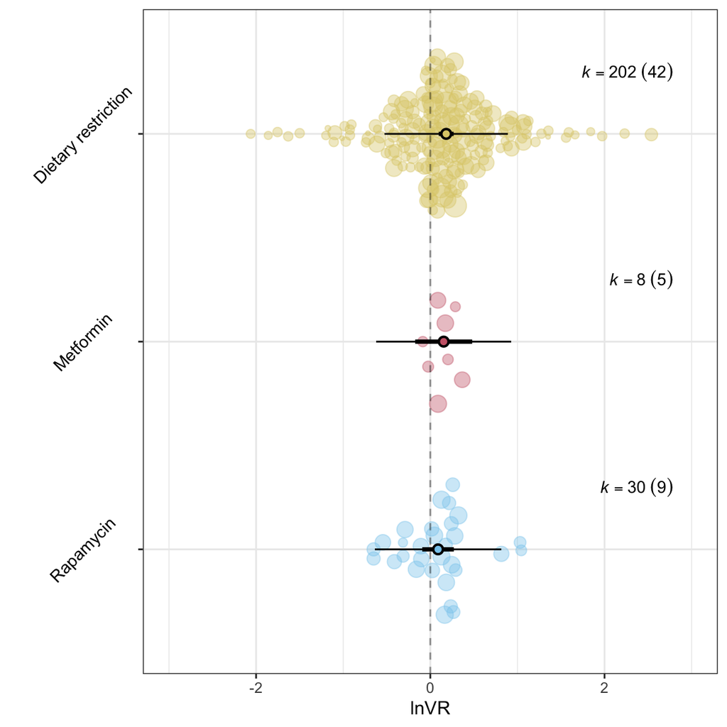

```r
res <- mod_results(m1, mod = "Treatment_Overall", data = Means_dat, group = "Study_ID")

Fig1A <- orchard_plot(res,
                     mod = "Treatment_Overall",
                     group = "Study_ID",
                     xlab = "lnVR",
                     alpha = 0.4) +
        theme(axis.text.y = element_text(angle = 45))+ theme(legend.position = "none") + ylim(-3, 3) + geom_point(size = 1.5, shape = 124)

Fig1A
```

#### Corrected for PB

Results remain consistent

```r
m1a <- rma.mv(yi=lnVR, V=v_lnVR, mods=~Treatment_Overall-1 + small_n + scale(Year, scale=F) , random=list(~1|Species, ~1|Study_ID, ~1|ID), data=Means_dat, method="REML", test="t")
m1a
```

```
##
## Multivariate Meta-Analysis Model (k = 240; method: REML)
##
## Variance Components:
##
##             estim    sqrt  nlvls  fixed    factor
## sigma^2.1  0.0000  0.0000      5     no   Species
## sigma^2.2  0.0267  0.1634     54     no  Study_ID
## sigma^2.3  0.1026  0.3203    240     no        ID
##
## Test for Residual Heterogeneity:
## QE(df = 235) = 791.9438, p-val < .0001
##
## Test of Moderators (coefficients 1:5):
## F(df1 = 5, df2 = 235) = 3.8897, p-val = 0.0021
##
## Model Results:
##
##                                       estimate      se     tval   df    pval
## Treatment_OverallRapamycin              0.1258  0.1022   1.2310  235  0.2196
## Treatment_OverallMetformin              0.1831  0.1736   1.0548  235  0.2926
## Treatment_OverallDietary restriction    0.1993  0.0594   3.3555  235  0.0009
## small_n                                -0.2351  0.3744  -0.6280  235  0.5306
## scale(Year, scale = F)                 -0.0016  0.0024  -0.6594  235  0.5103
##                                         ci.lb   ci.ub
## Treatment_OverallRapamycin            -0.0755  0.3271
## Treatment_OverallMetformin            -0.1589  0.5251
## Treatment_OverallDietary restriction   0.0823  0.3164  ***
## small_n                               -0.9728  0.5025
## scale(Year, scale = F)                -0.0063  0.0031
##
## ---
## Signif. codes:  0 '***' 0.001 '**' 0.01 '*' 0.05 '.' 0.1 ' ' 1
```

```r
r2_ml(m1a)
```

```
##    R2_marginal R2_conditional
##     0.02314066     0.22486953
```

### With intercept

- Met and Rapa don’t sig differ from DR
- treatment explains little of the total variation

```r
Means_dat$Treatment_Overall <- fct_rev(Means_dat$Treatment_Overall)
m1b <- rma.mv(yi=lnVR, V=v_lnVR, mods=~Treatment_Overall, random=list(~1|Species, ~1|Study_ID, ~1|ID), data=Means_dat, method="REML", test="t")
m1b
```

```
##
## Multivariate Meta-Analysis Model (k = 240; method: REML)
##
## Variance Components:
##
##             estim    sqrt  nlvls  fixed    factor
## sigma^2.1  0.0000  0.0000      5     no   Species
## sigma^2.2  0.0222  0.1490     54     no  Study_ID
## sigma^2.3  0.1050  0.3240    240     no        ID
##
## Test for Residual Heterogeneity:
## QE(df = 237) = 794.3086, p-val < .0001
##
## Test of Moderators (coefficients 2:3):
## F(df1 = 2, df2 = 237) = 0.4232, p-val = 0.6554
##
## Model Results:
##
##                             estimate      se     tval   df    pval    ci.lb
## intrcpt                       0.1821  0.0431   4.2210  237  <.0001   0.0971
## Treatment_OverallMetformin   -0.0289  0.1715  -0.1683  237  0.8665  -0.3667
## Treatment_OverallRapamycin   -0.0931  0.1016  -0.9170  237  0.3601  -0.2932
##                              ci.ub
## intrcpt                     0.2671  ***
## Treatment_OverallMetformin  0.3090
## Treatment_OverallRapamycin  0.1069
##
## ---
## Signif. codes:  0 '***' 0.001 '**' 0.01 '*' 0.05 '.' 0.1 ' ' 1
```

```r
r2_ml(m1)
```

```
##    R2_marginal R2_conditional
##    0.007470277    0.180630669
```

#### Corrected for PB

Results remain consistent treatment and PB explain little of variation

```r
m1c <- rma.mv(yi=lnVR, V=v_lnVR, mods=~Treatment_Overall + small_n + scale(Year, scale=F) , random=list(~1|Species, ~1|Study_ID, ~1|ID), data=Means_dat, method="REML", test="t")
m1c
```

```
##
## Multivariate Meta-Analysis Model (k = 240; method: REML)
##
## Variance Components:
##
##             estim    sqrt  nlvls  fixed    factor
## sigma^2.1  0.0000  0.0000      5     no   Species
## sigma^2.2  0.0267  0.1634     54     no  Study_ID
## sigma^2.3  0.1026  0.3203    240     no        ID
##
## Test for Residual Heterogeneity:
## QE(df = 235) = 791.9438, p-val < .0001
##
## Test of Moderators (coefficients 2:5):
## F(df1 = 4, df2 = 235) = 0.4200, p-val = 0.7942
##
## Model Results:
##
##                             estimate      se     tval   df    pval    ci.lb
## intrcpt                       0.1993  0.0594   3.3555  235  0.0009   0.0823
## Treatment_OverallMetformin   -0.0163  0.1739  -0.0935  235  0.9256  -0.3589
## Treatment_OverallRapamycin   -0.0736  0.1107  -0.6645  235  0.5070  -0.2917
## small_n                      -0.2351  0.3744  -0.6280  235  0.5306  -0.9728
## scale(Year, scale = F)       -0.0016  0.0024  -0.6594  235  0.5103  -0.0063
##                              ci.ub
## intrcpt                     0.3164  ***
## Treatment_OverallMetformin  0.3264
## Treatment_OverallRapamycin  0.1445
## small_n                     0.5025
## scale(Year, scale = F)      0.0031
##
## ---
## Signif. codes:  0 '***' 0.001 '**' 0.01 '*' 0.05 '.' 0.1 ' ' 1
```

```r
r2_ml(m1c)
```

```
##    R2_marginal R2_conditional
##     0.02314066     0.22486953
```

### Sex

Only looked at males and females (excluded mixed sex studies)

```r
Sex_subset <- subset(Means_dat, Sex != "mixed")
Sex_subset$Sex <- as.factor(Sex_subset$Sex)
```

#### Overall effect across all treatments

- Both males and females having increased variance with lifespan treatment (m2, m2a)
- Sex explains minimal variation
- The sexes don’t differ from each other (m2b, m2c)

##### Without intercept

```r
m2 <-rma.mv(yi=lnVR, V=v_lnVR, mods=~Sex-1, random=list(~1|Species, ~1|Study_ID, ~1|ID), data=Sex_subset, method="REML", test="t")
m2
```

```
##
## Multivariate Meta-Analysis Model (k = 225; method: REML)
##
## Variance Components:
##
##             estim    sqrt  nlvls  fixed    factor
## sigma^2.1  0.0000  0.0000      5     no   Species
## sigma^2.2  0.0219  0.1481     50     no  Study_ID
## sigma^2.3  0.1110  0.3332    225     no        ID
##
## Test for Residual Heterogeneity:
## QE(df = 223) = 765.5957, p-val < .0001
##
## Test of Moderators (coefficients 1:2):
## F(df1 = 2, df2 = 223) = 8.9159, p-val = 0.0002
##
## Model Results:
##
##            estimate      se    tval   df    pval   ci.lb   ci.ub
## Sexfemale    0.1880  0.0533  3.5291  223  0.0005  0.0830  0.2930  ***
## Sexmale      0.1507  0.0501  3.0067  223  0.0029  0.0519  0.2494   **
##
## ---
## Signif. codes:  0 '***' 0.001 '**' 0.01 '*' 0.05 '.' 0.1 ' ' 1
```

```r
r2_ml(m2)
```

```
##    R2_marginal R2_conditional
##    0.002618741    0.167084710
```

###### Correcting for PB

Results remain consistent

```r
m2a <- rma.mv(yi=lnVR, V=v_lnVR, mods=~Sex-1 + small_n + scale(Year, scale=F) , random=list(~1|Species, ~1|Study_ID, ~1|ID), data=Sex_subset, method="REML", test="t")
m2a
```

```
##
## Multivariate Meta-Analysis Model (k = 225; method: REML)
##
## Variance Components:
##
##             estim    sqrt  nlvls  fixed    factor
## sigma^2.1  0.0000  0.0000      5     no   Species
## sigma^2.2  0.0277  0.1663     50     no  Study_ID
## sigma^2.3  0.1069  0.3270    225     no        ID
##
## Test for Residual Heterogeneity:
## QE(df = 221) = 761.9109, p-val < .0001
##
## Test of Moderators (coefficients 1:4):
## F(df1 = 4, df2 = 221) = 4.5680, p-val = 0.0015
##
## Model Results:
##
##                         estimate      se     tval   df    pval    ci.lb   ci.ub
## Sexfemale                 0.2156  0.0665   3.2425  221  0.0014   0.0845  0.3466
## Sexmale                   0.1822  0.0637   2.8587  221  0.0047   0.0566  0.3078
## small_n                  -0.3182  0.3834  -0.8302  221  0.4073  -1.0737  0.4372
## scale(Year, scale = F)   -0.0019  0.0024  -0.7920  221  0.4292  -0.0065  0.0028
##
## Sexfemale               **
## Sexmale                 **
## small_n
## scale(Year, scale = F)
##
## ---
## Signif. codes:  0 '***' 0.001 '**' 0.01 '*' 0.05 '.' 0.1 ' ' 1
```

```r
r2_ml(m2a)
```

```
##    R2_marginal R2_conditional
##     0.03507792     0.23346750
```

##### With intercept

```r
m2b <-  rma.mv(yi=lnVR, V=v_lnVR, mods=~Sex, random=list(~1|Species, ~1|Study_ID, ~1|ID), data=Sex_subset, method="REML", test="t")
m2b
```

```
##
## Multivariate Meta-Analysis Model (k = 225; method: REML)
##
## Variance Components:
##
##             estim    sqrt  nlvls  fixed    factor
## sigma^2.1  0.0000  0.0000      5     no   Species
## sigma^2.2  0.0219  0.1481     50     no  Study_ID
## sigma^2.3  0.1110  0.3332    225     no        ID
##
## Test for Residual Heterogeneity:
## QE(df = 223) = 765.5957, p-val < .0001
##
## Test of Moderators (coefficient 2):
## F(df1 = 1, df2 = 223) = 0.3296, p-val = 0.5665
##
## Model Results:
##
##          estimate      se     tval   df    pval    ci.lb   ci.ub
## intrcpt    0.1880  0.0533   3.5291  223  0.0005   0.0830  0.2930  ***
## Sexmale   -0.0373  0.0651  -0.5741  223  0.5665  -0.1655  0.0908
##
## ---
## Signif. codes:  0 '***' 0.001 '**' 0.01 '*' 0.05 '.' 0.1 ' ' 1
```

###### Correcting for PB

Results remain consistent

```r
m2c <- rma.mv(yi=lnVR, V=v_lnVR, mods=~Sex + small_n + scale(Year, scale=F) , random=list(~1|Species, ~1|Study_ID, ~1|ID), data=Sex_subset, method="REML", test="t")
m2c
```

```
##
## Multivariate Meta-Analysis Model (k = 225; method: REML)
##
## Variance Components:
##
##             estim    sqrt  nlvls  fixed    factor
## sigma^2.1  0.0000  0.0000      5     no   Species
## sigma^2.2  0.0277  0.1663     50     no  Study_ID
## sigma^2.3  0.1069  0.3270    225     no        ID
##
## Test for Residual Heterogeneity:
## QE(df = 221) = 761.9109, p-val < .0001
##
## Test of Moderators (coefficients 2:4):
## F(df1 = 3, df2 = 221) = 0.5575, p-val = 0.6437
##
## Model Results:
##
##                         estimate      se     tval   df    pval    ci.lb   ci.ub
## intrcpt                   0.2156  0.0665   3.2425  221  0.0014   0.0845  0.3466
## Sexmale                  -0.0334  0.0652  -0.5122  221  0.6090  -0.1618  0.0951
## small_n                  -0.3182  0.3834  -0.8302  221  0.4073  -1.0737  0.4372
## scale(Year, scale = F)   -0.0019  0.0024  -0.7920  221  0.4292  -0.0065  0.0028
##
## intrcpt                 **
## Sexmale
## small_n
## scale(Year, scale = F)
##
## ---
## Signif. codes:  0 '***' 0.001 '**' 0.01 '*' 0.05 '.' 0.1 ' ' 1
```

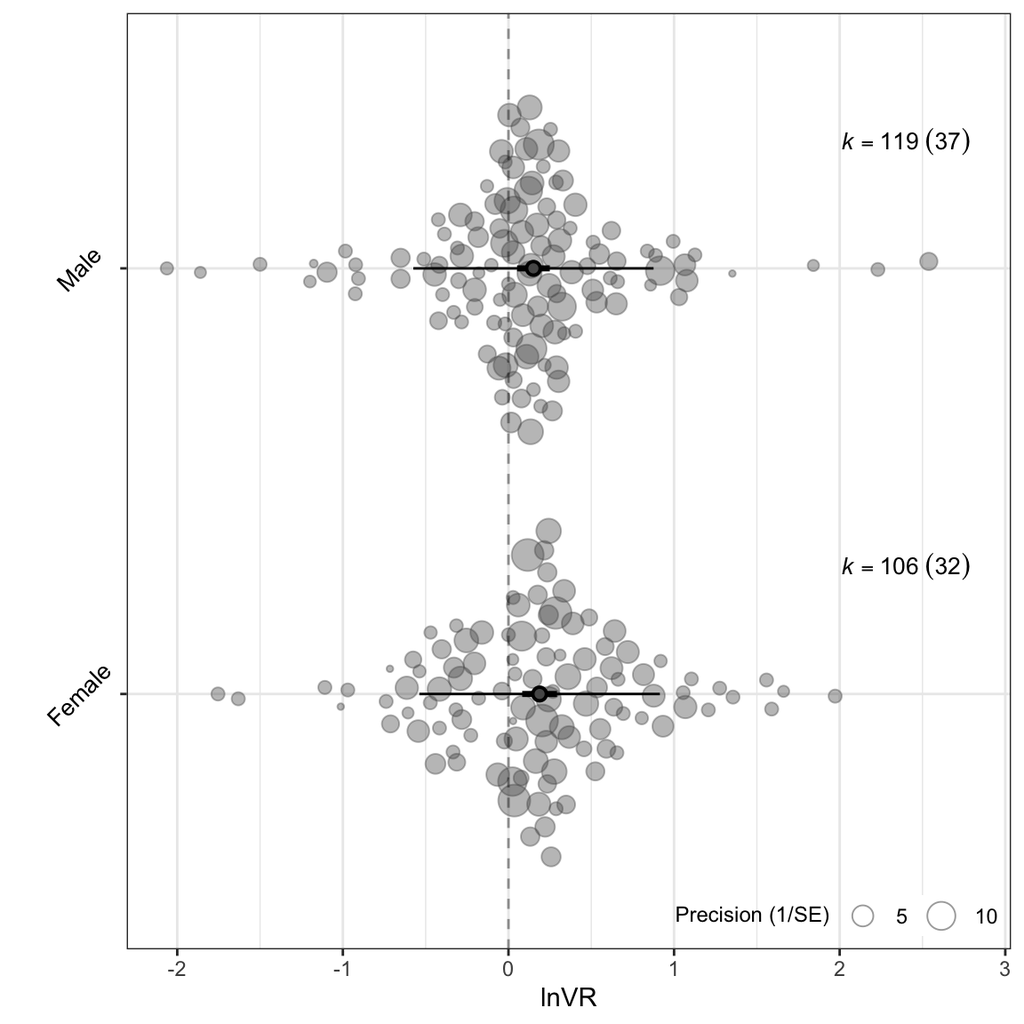

```r
res <- mod_results(m2, mod = "Sex", data = Sex_subset, group = "Study_ID")

Fig2 <- orchard_plot(res, mod = "Sex", group = "Study_ID", xlab = "lnVR", alpha=0.4) +
theme(axis.text.y = element_text(angle = 45))+ scale_colour_manual(values = c("grey34","grey34")) + scale_fill_manual(values = c("grey34","grey34"))

Fig2
```

#### DR

```r
DR <- subset(Sex_subset, Treatment_Overall == "Dietary restriction")
```

##### Without intercept

```r
m3 <-rma.mv(yi=lnVR, V=v_lnVR, mods=~Sex-1, random=list(~1|Species, ~1|Study_ID, ~1|ID), data=DR, method="REML", test="t")
m3
```

```
##
## Multivariate Meta-Analysis Model (k = 193; method: REML)
##
## Variance Components:
##
##             estim    sqrt  nlvls  fixed    factor
## sigma^2.1  0.0000  0.0000      5     no   Species
## sigma^2.2  0.0255  0.1596     38     no  Study_ID
## sigma^2.3  0.1319  0.3632    193     no        ID
##
## Test for Residual Heterogeneity:
## QE(df = 191) = 692.3332, p-val < .0001
##
## Test of Moderators (coefficients 1:2):
## F(df1 = 2, df2 = 191) = 7.3262, p-val = 0.0009
##
## Model Results:
##
##            estimate      se    tval   df    pval   ci.lb   ci.ub
## Sexfemale    0.2080  0.0654  3.1831  191  0.0017  0.0791  0.3369  **
## Sexmale      0.1658  0.0587  2.8254  191  0.0052  0.0501  0.2816  **
##
## ---
## Signif. codes:  0 '***' 0.001 '**' 0.01 '*' 0.05 '.' 0.1 ' ' 1
```

```r
r2_ml(m3)
```

```
##    R2_marginal R2_conditional
##    0.002815861    0.164287773
```

###### Correcting for PB

Results remain consistent

```r
m3a <- rma.mv(yi=lnVR, V=v_lnVR, mods=~Sex-1 + small_n + scale(Year, scale=F) , random=list(~1|Species, ~1|Study_ID, ~1|ID), data=DR, method="REML", test="t")
m3a
```

```
##
## Multivariate Meta-Analysis Model (k = 193; method: REML)
##
## Variance Components:
##
##             estim    sqrt  nlvls  fixed    factor
## sigma^2.1  0.0000  0.0000      5     no   Species
## sigma^2.2  0.0336  0.1833     38     no  Study_ID
## sigma^2.3  0.1276  0.3573    193     no        ID
##
## Test for Residual Heterogeneity:
## QE(df = 189) = 690.2071, p-val < .0001
##
## Test of Moderators (coefficients 1:4):
## F(df1 = 4, df2 = 189) = 3.6313, p-val = 0.0071
##
## Model Results:
##
##                         estimate      se     tval   df    pval    ci.lb   ci.ub
## Sexfemale                 0.2422  0.0821   2.9511  189  0.0036   0.0803  0.4041
## Sexmale                   0.2045  0.0757   2.7035  189  0.0075   0.0553  0.3538
## small_n                  -0.3752  0.4385  -0.8555  189  0.3934  -1.2403  0.4899
## scale(Year, scale = F)   -0.0011  0.0027  -0.4084  189  0.6835  -0.0065  0.0042
##
## Sexfemale               **
## Sexmale                 **
## small_n
## scale(Year, scale = F)
##
## ---
## Signif. codes:  0 '***' 0.001 '**' 0.01 '*' 0.05 '.' 0.1 ' ' 1
```

```r
r2_ml(m3a)
```

```
##    R2_marginal R2_conditional
##      0.0358855      0.2368286
```

##### With intercept

The sexes don’t differ from each other in their response

```r
m3b <-  rma.mv(yi=lnVR, V=v_lnVR, mods=~Sex, random=list(~1|Species, ~1|Study_ID, ~1|ID), data=DR, method="REML", test="t")
m3b
```

```
##
## Multivariate Meta-Analysis Model (k = 193; method: REML)
##
## Variance Components:
##
##             estim    sqrt  nlvls  fixed    factor
## sigma^2.1  0.0000  0.0000      5     no   Species
## sigma^2.2  0.0255  0.1596     38     no  Study_ID
## sigma^2.3  0.1319  0.3632    193     no        ID
##
## Test for Residual Heterogeneity:
## QE(df = 191) = 692.3332, p-val < .0001
##
## Test of Moderators (coefficient 2):
## F(df1 = 1, df2 = 191) = 0.3030, p-val = 0.5826
##
## Model Results:
##
##          estimate      se     tval   df    pval    ci.lb   ci.ub
## intrcpt    0.2080  0.0654   3.1831  191  0.0017   0.0791  0.3369  **
## Sexmale   -0.0422  0.0767  -0.5505  191  0.5826  -0.1935  0.1091
##
## ---
## Signif. codes:  0 '***' 0.001 '**' 0.01 '*' 0.05 '.' 0.1 ' ' 1
```

###### Correcting for PB

Results remain consistent

```r
m3c <- rma.mv(yi=lnVR, V=v_lnVR, mods=~Sex + small_n + scale(Year, scale=F) , random=list(~1|Species, ~1|Study_ID, ~1|ID), data=DR, method="REML", test="t")
m3c
```

```
##
## Multivariate Meta-Analysis Model (k = 193; method: REML)
##
## Variance Components:
##
##             estim    sqrt  nlvls  fixed    factor
## sigma^2.1  0.0000  0.0000      5     no   Species
## sigma^2.2  0.0336  0.1833     38     no  Study_ID
## sigma^2.3  0.1276  0.3573    193     no        ID
##
## Test for Residual Heterogeneity:
## QE(df = 189) = 690.2071, p-val < .0001
##
## Test of Moderators (coefficients 2:4):
## F(df1 = 3, df2 = 189) = 0.4071, p-val = 0.7480
##
## Model Results:
##
##                         estimate      se     tval   df    pval    ci.lb   ci.ub
## intrcpt                   0.2422  0.0821   2.9511  189  0.0036   0.0803  0.4041
## Sexmale                  -0.0377  0.0773  -0.4871  189  0.6268  -0.1902  0.1149
## small_n                  -0.3752  0.4385  -0.8555  189  0.3934  -1.2403  0.4899
## scale(Year, scale = F)   -0.0011  0.0027  -0.4084  189  0.6835  -0.0065  0.0042
##
## intrcpt                 **
## Sexmale
## small_n
## scale(Year, scale = F)
##
## ---
## Signif. codes:  0 '***' 0.001 '**' 0.01 '*' 0.05 '.' 0.1 ' ' 1
```

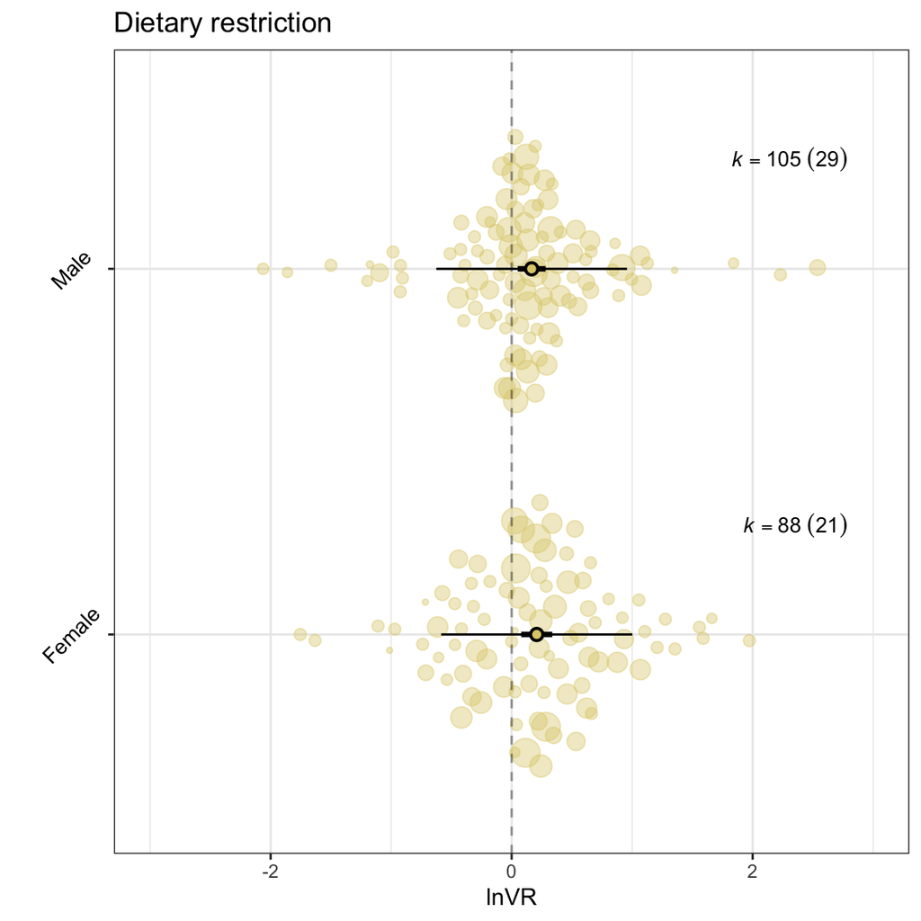

```r
res <- mod_results(m3, mod = "Sex", data = DR, group = "Study_ID")

Fig1_DR <- orchard_plot(res, mod = "Sex", group = "Study_ID", xlab = "lnVR", alpha=0.4) +
theme(axis.text.y = element_text(angle = 45)) + scale_colour_manual(values = c("#DDCC77","#DDCC77"))  + scale_fill_manual(values = c("#DDCC77","#DDCC77")) + ggtitle("Dietary restriction")+ theme(legend.position = "none") + ylim(-3, 3)

Fig1_DR
```

#### Rapamycin

```r
Rapa <- subset(Sex_subset, Treatment_Overall == "Rapamycin")
```

##### Without intercept

```r
#without intercept: Rapa is not significant in either sex
m4 <-rma.mv(yi=lnVR, V=v_lnVR, mods=~Sex-1, random=list(~1|Species, ~1|Study_ID, ~1|ID), data=Rapa, method="REML", test="t")
m4
```

```
##
## Multivariate Meta-Analysis Model (k = 24; method: REML)
##
## Variance Components:
##
##             estim    sqrt  nlvls  fixed    factor
## sigma^2.1  0.0000  0.0000      1    yes   Species
## sigma^2.2  0.0000  0.0000      8     no  Study_ID
## sigma^2.3  0.0868  0.2946     24     no        ID
##
## Test for Residual Heterogeneity:
## QE(df = 22) = 66.4561, p-val < .0001
##
## Test of Moderators (coefficients 1:2):
## F(df1 = 2, df2 = 22) = 0.8058, p-val = 0.4595
##
## Model Results:
##
##            estimate      se    tval  df    pval    ci.lb   ci.ub
## Sexfemale    0.1204  0.0987  1.2195  22  0.2356  -0.0843  0.3251
## Sexmale      0.0404  0.1147  0.3527  22  0.7277  -0.1974  0.2782
##
## ---
## Signif. codes:  0 '***' 0.001 '**' 0.01 '*' 0.05 '.' 0.1 ' ' 1
```

```r
r2_ml(m4)
```

```
##    R2_marginal R2_conditional
##     0.01833171     0.01833171
```

###### Correcting for PB

Results remain consistent

```r
m4a <- rma.mv(yi=lnVR, V=v_lnVR, mods=~Sex-1 + small_n + scale(Year, scale=F) , random=list(~1|Species, ~1|Study_ID, ~1|ID), data=Rapa, method="REML", test="t")
m4a
```

```
##
## Multivariate Meta-Analysis Model (k = 24; method: REML)
##
## Variance Components:
##
##             estim    sqrt  nlvls  fixed    factor
## sigma^2.1  0.0000  0.0000      1    yes   Species
## sigma^2.2  0.0560  0.2367      8     no  Study_ID
## sigma^2.3  0.0475  0.2179     24     no        ID
##
## Test for Residual Heterogeneity:
## QE(df = 20) = 65.3208, p-val < .0001
##
## Test of Moderators (coefficients 1:4):
## F(df1 = 4, df2 = 20) = 0.5663, p-val = 0.6900
##
## Model Results:
##
##                         estimate      se     tval  df    pval    ci.lb   ci.ub
## Sexfemale                 0.0404  0.1794   0.2253  20  0.8241  -0.3338  0.4147
## Sexmale                   0.0208  0.1815   0.1149  20  0.9097  -0.3578  0.3995
## small_n                   0.5079  1.6503   0.3077  20  0.7615  -2.9345  3.9502
## scale(Year, scale = F)   -0.0296  0.0273  -1.0854  20  0.2906  -0.0866  0.0273
##
## Sexfemale
## Sexmale
## small_n
## scale(Year, scale = F)
##
## ---
## Signif. codes:  0 '***' 0.001 '**' 0.01 '*' 0.05 '.' 0.1 ' ' 1
```

```r
r2_ml(m4a)
```

```
##    R2_marginal R2_conditional
##      0.1134262      0.5931969
```

##### With intercept

```r
#With intercept. The sexes don't differ from each other in their response
m4b <-  rma.mv(yi=lnVR, V=v_lnVR, mods=~Sex, random=list(~1|Species, ~1|Study_ID, ~1|ID), data=Rapa, method="REML", test="t")
m4b
```

```
##
## Multivariate Meta-Analysis Model (k = 24; method: REML)
##
## Variance Components:
##
##             estim    sqrt  nlvls  fixed    factor
## sigma^2.1  0.0000  0.0000      1    yes   Species
## sigma^2.2  0.0000  0.0000      8     no  Study_ID
## sigma^2.3  0.0868  0.2946     24     no        ID
##
## Test for Residual Heterogeneity:
## QE(df = 22) = 66.4561, p-val < .0001
##
## Test of Moderators (coefficient 2):
## F(df1 = 1, df2 = 22) = 0.2791, p-val = 0.6026
##
## Model Results:
##
##          estimate      se     tval  df    pval    ci.lb   ci.ub
## intrcpt    0.1204  0.0987   1.2195  22  0.2356  -0.0843  0.3251
## Sexmale   -0.0799  0.1513  -0.5283  22  0.6026  -0.3937  0.2338
##
## ---
## Signif. codes:  0 '***' 0.001 '**' 0.01 '*' 0.05 '.' 0.1 ' ' 1
```

###### Correcting for PB

Results remain consistent

```r
m4c <- rma.mv(yi=lnVR, V=v_lnVR, mods=~Sex + small_n + scale(Year, scale=F) , random=list(~1|Species, ~1|Study_ID, ~1|ID), data=Rapa, method="REML", test="t")
m4c
```

```
##
## Multivariate Meta-Analysis Model (k = 24; method: REML)
##
## Variance Components:
##
##             estim    sqrt  nlvls  fixed    factor
## sigma^2.1  0.0000  0.0000      1    yes   Species
## sigma^2.2  0.0560  0.2367      8     no  Study_ID
## sigma^2.3  0.0475  0.2179     24     no        ID
##
## Test for Residual Heterogeneity:
## QE(df = 20) = 65.3208, p-val < .0001
##
## Test of Moderators (coefficients 2:4):
## F(df1 = 3, df2 = 20) = 0.4357, p-val = 0.7299
##
## Model Results:
##
##                         estimate      se     tval  df    pval    ci.lb   ci.ub
## intrcpt                   0.0404  0.1794   0.2253  20  0.8241  -0.3338  0.4147
## Sexmale                  -0.0196  0.1315  -0.1488  20  0.8832  -0.2938  0.2547
## small_n                   0.5079  1.6503   0.3077  20  0.7615  -2.9345  3.9502
## scale(Year, scale = F)   -0.0296  0.0273  -1.0854  20  0.2906  -0.0866  0.0273
##
## intrcpt
## Sexmale
## small_n
## scale(Year, scale = F)
##
## ---
## Signif. codes:  0 '***' 0.001 '**' 0.01 '*' 0.05 '.' 0.1 ' ' 1
```

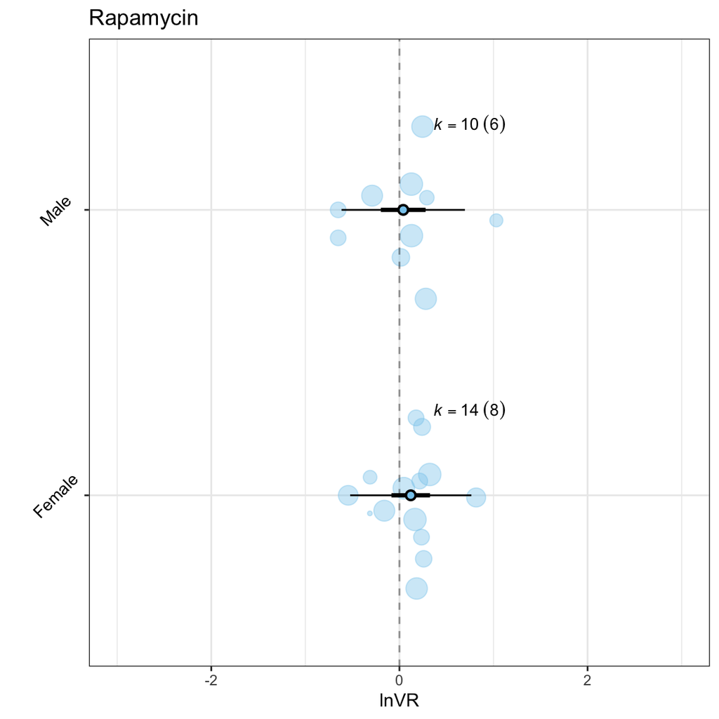

```r
res <- mod_results(m4, mod = "Sex", data = Rapa, group = "Study_ID")

Fig1_rap <- orchard_plot(res, mod = "Sex", group = "Study_ID", xlab = "lnVR", alpha=0.4) +
theme(axis.text.y = element_text(angle = 45))+ scale_colour_manual(values = c("#88CCEE","#88CCEE"))  + scale_fill_manual(values = c("#88CCEE","#88CCEE")) + ggtitle("Rapamycin")+ theme(legend.position = "none")+ ylim(-3, 3)
Fig1_rap
```

#### Metformin

```r
Met <- subset(Sex_subset, Treatment_Overall == "Metformin")
```

##### Without intercept

```r
#Needed to use an optimiser (same as original paper)
m5 <-rma.mv(yi=lnVR, V=v_lnVR, mods=~Sex-1, random=list(~1|Species, ~1|Study_ID, ~1|ID), data=Met, method="REML", test="t", control = list(optimizer = "optim", optmethod = "Nelder-Mead"))
m5
```

```
##
## Multivariate Meta-Analysis Model (k = 8; method: REML)
##
## Variance Components:
##
##             estim    sqrt  nlvls  fixed    factor
## sigma^2.1  0.0000  0.0000      2     no   Species
## sigma^2.2  0.0000  0.0000      5     no  Study_ID
## sigma^2.3  0.0000  0.0000      8     no        ID
##
## Test for Residual Heterogeneity:
## QE(df = 6) = 2.1828, p-val = 0.9021
##
## Test of Moderators (coefficients 1:2):
## F(df1 = 2, df2 = 6) = 2.2078, p-val = 0.1912
##
## Model Results:
##
##            estimate      se    tval  df    pval    ci.lb   ci.ub
## Sexfemale    0.1831  0.1053  1.7396   6  0.1326  -0.0745  0.4407
## Sexmale      0.1295  0.1099  1.1787   6  0.2831  -0.1393  0.3983
##
## ---
## Signif. codes:  0 '***' 0.001 '**' 0.01 '*' 0.05 '.' 0.1 ' ' 1
```

```r
r2_ml(m5)
```

```
##    R2_marginal R2_conditional
##              1              1
```

###### Correcting for PB

Results remain consistent

```r
m5a <- rma.mv(yi=lnVR, V=v_lnVR, mods=~Sex-1 + small_n + scale(Year, scale=F) , random=list(~1|Species, ~1|Study_ID, ~1|ID), data=Met, method="REML", test="t", control = list(optimizer = "optim", optmethod = "Nelder-Mead"))
m5a
```

```
##
## Multivariate Meta-Analysis Model (k = 8; method: REML)
##
## Variance Components:
##
##             estim    sqrt  nlvls  fixed    factor
## sigma^2.1  0.0000  0.0000      2     no   Species
## sigma^2.2  0.0000  0.0000      5     no  Study_ID
## sigma^2.3  0.0000  0.0000      8     no        ID
##
## Test for Residual Heterogeneity:
## QE(df = 4) = 0.7538, p-val = 0.9445
##
## Test of Moderators (coefficients 1:4):
## F(df1 = 4, df2 = 4) = 1.4611, p-val = 0.3611
##
## Model Results:
##
##                         estimate      se     tval  df    pval    ci.lb   ci.ub
## Sexfemale                 0.1753  0.1297   1.3508   4  0.2481  -0.1850  0.5355
## Sexmale                   0.3671  0.2311   1.5883   4  0.1874  -0.2746  1.0089
## small_n                  -0.7793  1.0900  -0.7149   4  0.5142  -3.8058  2.2472
## scale(Year, scale = F)   -0.0851  0.0723  -1.1766   4  0.3046  -0.2860  0.1157
##
## Sexfemale
## Sexmale
## small_n
## scale(Year, scale = F)
##
## ---
## Signif. codes:  0 '***' 0.001 '**' 0.01 '*' 0.05 '.' 0.1 ' ' 1
```

```r
r2_ml(m5a)
```

```
##    R2_marginal R2_conditional
##              1              1
```

##### With intercept

```r
m5b <-  rma.mv(yi=lnVR, V=v_lnVR, mods=~Sex, random=list(~1|Species, ~1|Study_ID, ~1|ID), data=Met, method="REML", test="t", control = list(optimizer = "optim", optmethod = "Nelder-Mead"))+ theme(legend.position = "none")
m5b
```

[output not shown]

###### Correcting for PB

Results remain consistent

```r
m5c <- rma.mv(yi=lnVR, V=v_lnVR, mods=~Sex + small_n + scale(Year, scale=F) , random=list(~1|Species, ~1|Study_ID, ~1|ID), data=Met, method="REML", test="t", control = list(optimizer = "optim", optmethod = "Nelder-Mead"))
m5c
```

```
##
## Multivariate Meta-Analysis Model (k = 8; method: REML)
##
## Variance Components:
##
##             estim    sqrt  nlvls  fixed    factor
## sigma^2.1  0.0000  0.0000      2     no   Species
## sigma^2.2  0.0000  0.0000      5     no  Study_ID
## sigma^2.3  0.0000  0.0000      8     no        ID
##
## Test for Residual Heterogeneity:
## QE(df = 4) = 0.7538, p-val = 0.9445
##
## Test of Moderators (coefficients 2:4):
## F(df1 = 3, df2 = 4) = 0.5177, p-val = 0.6923
##
## Model Results:
##
##                         estimate      se     tval  df    pval    ci.lb   ci.ub
## intrcpt                   0.1753  0.1297   1.3508   4  0.2481  -0.1850  0.5355
## Sexmale                   0.1919  0.2577   0.7446   4  0.4979  -0.5235  0.9072
## small_n                  -0.7793  1.0900  -0.7149   4  0.5142  -3.8058  2.2472
## scale(Year, scale = F)   -0.0851  0.0723  -1.1766   4  0.3046  -0.2860  0.1157
##
## intrcpt
## Sexmale
## small_n
## scale(Year, scale = F)
##
## ---
## Signif. codes:  0 '***' 0.001 '**' 0.01 '*' 0.05 '.' 0.1 ' ' 1
```

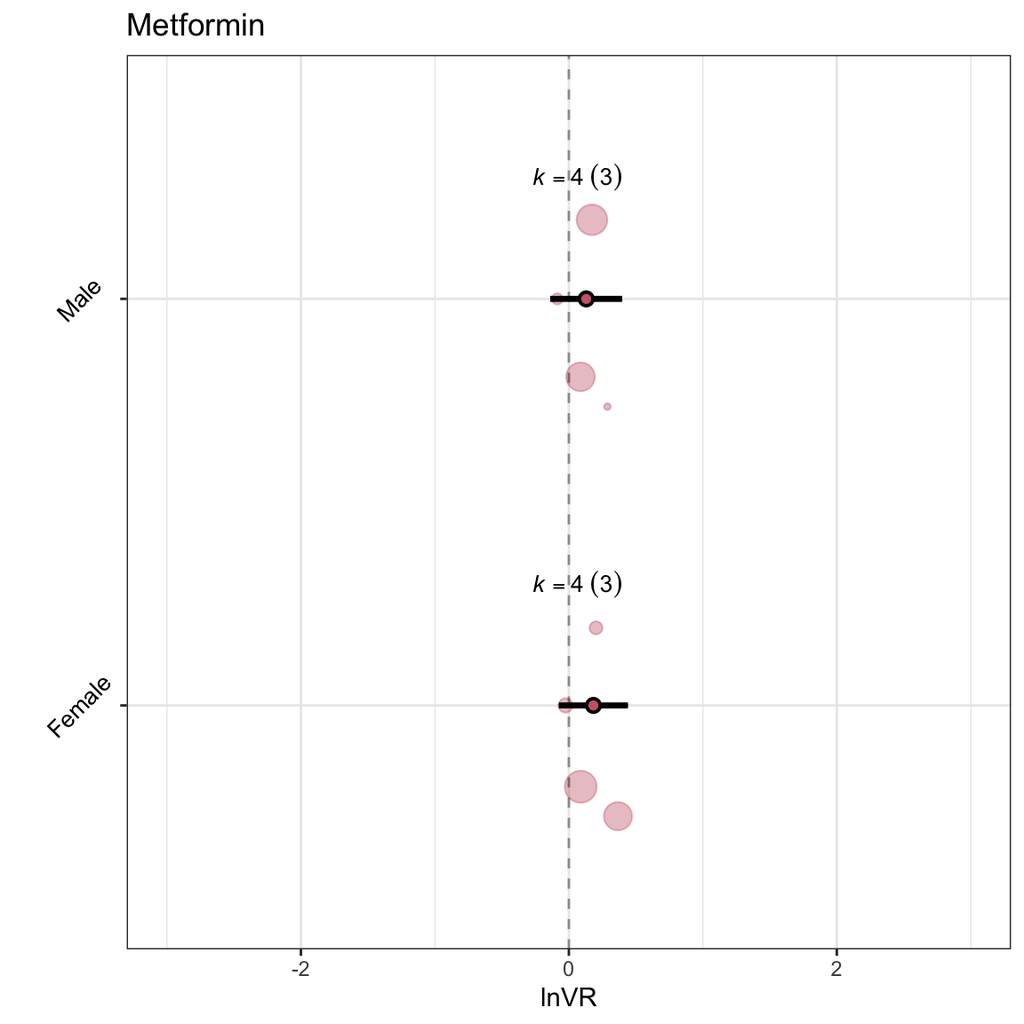

```r
res <- mod_results(m5, mod = "Sex", data = Met, group = "Study_ID")

Fig1_met <- orchard_plot(res, mod = "Sex", group = "Study_ID", xlab = "lnVR", alpha=0.4) +
theme(axis.text.y = element_text(angle = 45))+ scale_colour_manual(values = c("#CC6677","#CC6677"))  + scale_fill_manual(values = c("#CC6677","#CC6677")) + ggtitle("Metformin") + theme(legend.position = "none") + ylim(-3, 3)

Fig1_met
```

```r
Fig1A_sex <- (Fig1_DR / Fig1_met/ Fig1_rap)
```

## lnCVR

Changes in variance after accounting for changes in the mean + No increase in variation across treatments

### I2 across all diets

```r
m <- rma.mv(yi=lnCVR, V=v_lnCVR, random=list(~1|Species, ~1|Study_ID, ~1|ID), data=Means_dat, method="REML", test="t")
m
```

```
##
## Multivariate Meta-Analysis Model (k = 240; method: REML)
##
## Variance Components:
##
##             estim    sqrt  nlvls  fixed    factor
## sigma^2.1  0.0000  0.0000      5     no   Species
## sigma^2.2  0.0204  0.1428     54     no  Study_ID
## sigma^2.3  0.1284  0.3583    240     no        ID
##
## Test for Heterogeneity:
## Q(df = 239) = 806.7989, p-val < .0001
##
## Model Results:
##
## estimate      se    tval   df    pval    ci.lb   ci.ub
##   0.0563  0.0398  1.4148  239  0.1584  -0.0221  0.1347
##
## ---
## Signif. codes:  0 '***' 0.001 '**' 0.01 '*' 0.05 '.' 0.1 ' ' 1
```

```r
i2_ml(m)
```

```
##     I2_Total   I2_Species  I2_Study_ID        I2_ID
## 7.623027e+01 1.123205e-07 1.044860e+01 6.578167e+01
```

```r
# i2_ml(m, boot = 1000)
```

### Without intercept

- Treatments don’t increase variation after accounting for increases in the mean

```r
Means_dat$Treatment_Overall <- as.factor(Means_dat$Treatment_Overall)
# Means_dat$Treatment_Overall <- fct_rev(Means_dat$Treatment_Overall)
m1 <- rma.mv(yi=lnCVR, V=v_lnCVR, mods=~Treatment_Overall-1, random=list(~1|Species, ~1|Study_ID, ~1|ID), data=Means_dat, method="REML", test="t")
m1
```

```
##
## Multivariate Meta-Analysis Model (k = 240; method: REML)
##
## Variance Components:
##
##             estim    sqrt  nlvls  fixed    factor
## sigma^2.1  0.0000  0.0000      5     no   Species
## sigma^2.2  0.0222  0.1489     54     no  Study_ID
## sigma^2.3  0.1302  0.3608    240     no        ID
##
## Test for Residual Heterogeneity:
## QE(df = 237) = 806.6671, p-val < .0001
##
## Test of Moderators (coefficients 1:3):
## F(df1 = 3, df2 = 237) = 0.6451, p-val = 0.5868
##
## Model Results:
##
##                                       estimate      se    tval   df    pval
## Treatment_OverallDietary restriction    0.0531  0.0457  1.1616  237  0.2466
## Treatment_OverallMetformin              0.0774  0.1792  0.4321  237  0.6661
## Treatment_OverallRapamycin              0.0628  0.0980  0.6403  237  0.5226
##                                         ci.lb   ci.ub
## Treatment_OverallDietary restriction  -0.0370  0.1432
## Treatment_OverallMetformin            -0.2756  0.4305
## Treatment_OverallRapamycin            -0.1303  0.2558
##
## ---
## Signif. codes:  0 '***' 0.001 '**' 0.01 '*' 0.05 '.' 0.1 ' ' 1
```

```r
r2_ml(m1)
```

```
##    R2_marginal R2_conditional
##   0.0001796089   0.1457186058
```

#### Orchard plot

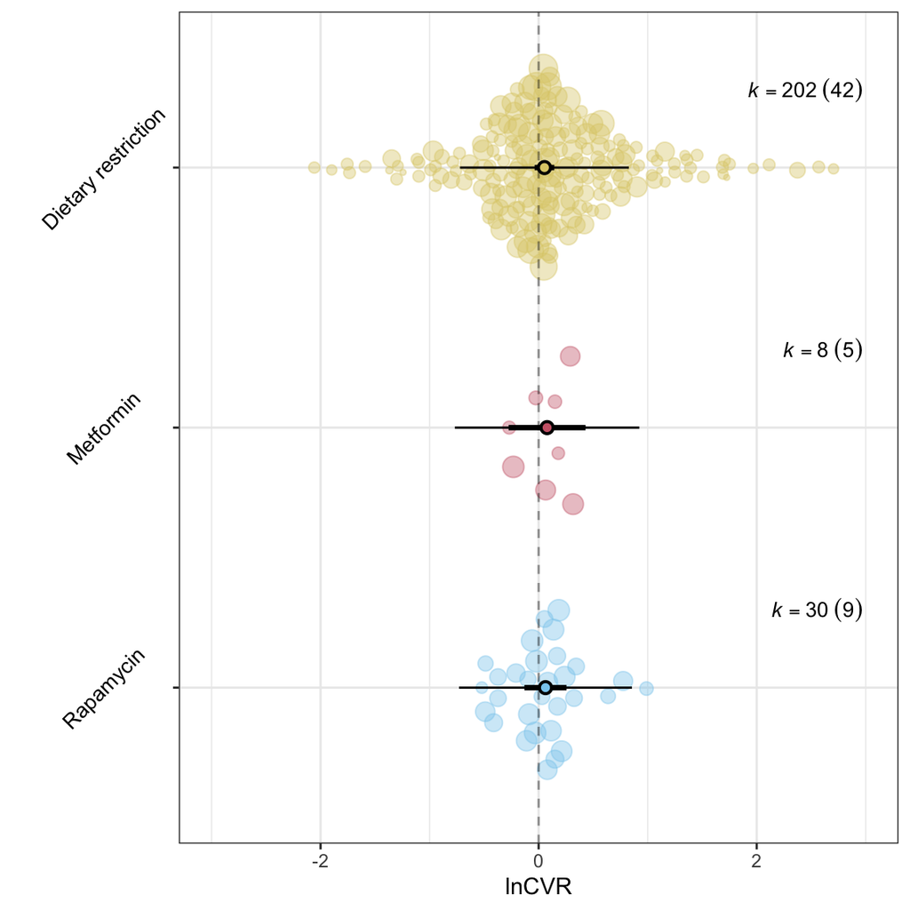

```r
Means_dat$Treatment_Overall <- fct_rev(Means_dat$Treatment_Overall)
m1 <- rma.mv(yi=lnCVR, V=v_lnCVR, mods=~Treatment_Overall-1, random=list(~1|Species, ~1|Study_ID, ~1|ID), data=Means_dat, method="REML", test="t")

res <- mod_results(m1, mod = "Treatment_Overall", data = Means_dat, group = "Study_ID")
# res$mod_levels <- rev(res$mod_levels)

Fig1B <- orchard_plot(res,
                     mod = "Treatment_Overall",
                     group = "Study_ID",
                     xlab = "lnCVR",
                     alpha = 0.4) +
        theme(axis.text.y = element_text(angle = 45))+ theme(legend.position = "none")+ ylim(-3, 3)

Fig1B
```

#### Corrected for PB

Results remain consistent

```r
m1a <- rma.mv(yi=lnCVR, V=v_lnCVR, mods=~Treatment_Overall-1 + small_n + scale(Year, scale=F) , random=list(~1|Species, ~1|Study_ID, ~1|ID), data=Means_dat, method="REML", test="t")
m1a
```

```
##
## Multivariate Meta-Analysis Model (k = 240; method: REML)
##
## Variance Components:
##
##             estim    sqrt  nlvls  fixed    factor
## sigma^2.1  0.0000  0.0000      5     no   Species
## sigma^2.2  0.0211  0.1451     54     no  Study_ID
## sigma^2.3  0.1336  0.3656    240     no        ID
##
## Test for Residual Heterogeneity:
## QE(df = 235) = 799.0749, p-val < .0001
##
## Test of Moderators (coefficients 1:5):
## F(df1 = 5, df2 = 235) = 0.5480, p-val = 0.7398
##
## Model Results:
##
##                                       estimate      se    tval   df    pval
## Treatment_OverallRapamycin              0.0299  0.1054  0.2839  235  0.7767
## Treatment_OverallMetformin              0.0390  0.1857  0.2099  235  0.8339
## Treatment_OverallDietary restriction    0.0245  0.0612  0.4000  235  0.6895
## small_n                                 0.3051  0.3703  0.8241  235  0.4107
## scale(Year, scale = F)                  0.0006  0.0025  0.2597  235  0.7953
##                                         ci.lb   ci.ub
## Treatment_OverallRapamycin            -0.1777  0.2376
## Treatment_OverallMetformin            -0.3268  0.4047
## Treatment_OverallDietary restriction  -0.0962  0.1451
## small_n                               -0.4243  1.0346
## scale(Year, scale = F)                -0.0042  0.0055
##
## ---
## Signif. codes:  0 '***' 0.001 '**' 0.01 '*' 0.05 '.' 0.1 ' ' 1
```

```r
r2_ml(m1a)
```

```
##    R2_marginal R2_conditional
##     0.01983752     0.15326075
```

### With intercept

Met and Rapa don’t sig differ from DR treatment explains little of the total variation

```r
Means_dat$Treatment_Overall <- fct_rev(Means_dat$Treatment_Overall)
m1b <- rma.mv(yi=lnCVR, V=v_lnCVR, mods=~Treatment_Overall, random=list(~1|Species, ~1|Study_ID, ~1|ID), data=Means_dat, method="REML", test="t")
m1b
```

```
##
## Multivariate Meta-Analysis Model (k = 240; method: REML)
##
## Variance Components:
##
##             estim    sqrt  nlvls  fixed    factor
## sigma^2.1  0.0000  0.0000      5     no   Species
## sigma^2.2  0.0222  0.1489     54     no  Study_ID
## sigma^2.3  0.1302  0.3608    240     no        ID
##
## Test for Residual Heterogeneity:
## QE(df = 237) = 806.6671, p-val < .0001
##
## Test of Moderators (coefficients 2:3):
## F(df1 = 2, df2 = 237) = 0.0116, p-val = 0.9885
##
## Model Results:
##
##                             estimate      se    tval   df    pval    ci.lb
## intrcpt                       0.0531  0.0457  1.1616  237  0.2466  -0.0370
## Treatment_OverallMetformin    0.0243  0.1847  0.1316  237  0.8954  -0.3396
## Treatment_OverallRapamycin    0.0096  0.1080  0.0892  237  0.9290  -0.2031
##                              ci.ub
## intrcpt                     0.1432
## Treatment_OverallMetformin  0.3882
## Treatment_OverallRapamycin  0.2224
##
## ---
## Signif. codes:  0 '***' 0.001 '**' 0.01 '*' 0.05 '.' 0.1 ' ' 1
```

```r
r2_ml(m1)
```

```
##    R2_marginal R2_conditional
##   0.0001796089   0.1457186059
```

#### Corrected for PB

Results remain consistent

```r
m1c <- rma.mv(yi=lnCVR, V=v_lnCVR, mods=~Treatment_Overall + small_n + scale(Year, scale=F) , random=list(~1|Species, ~1|Study_ID, ~1|ID), data=Means_dat, method="REML", test="t")
m1c
```

```
##
## Multivariate Meta-Analysis Model (k = 240; method: REML)
##
## Variance Components:
##
##             estim    sqrt  nlvls  fixed    factor
## sigma^2.1  0.0000  0.0000      5     no   Species
## sigma^2.2  0.0211  0.1451     54     no  Study_ID
## sigma^2.3  0.1336  0.3656    240     no        ID
##
## Test for Residual Heterogeneity:
## QE(df = 235) = 799.0749, p-val < .0001
##
## Test of Moderators (coefficients 2:5):
## F(df1 = 4, df2 = 235) = 0.1997, p-val = 0.9383
##
## Model Results:
##
##                             estimate      se    tval   df    pval    ci.lb
## intrcpt                       0.0245  0.0612  0.4000  235  0.6895  -0.0962
## Treatment_OverallMetformin    0.0145  0.1860  0.0778  235  0.9380  -0.3520
## Treatment_OverallRapamycin    0.0054  0.1143  0.0475  235  0.9621  -0.2198
## small_n                       0.3051  0.3703  0.8241  235  0.4107  -0.4243
## scale(Year, scale = F)        0.0006  0.0025  0.2597  235  0.7953  -0.0042
##                              ci.ub
## intrcpt                     0.1451
## Treatment_OverallMetformin  0.3809
## Treatment_OverallRapamycin  0.2307
## small_n                     1.0346
## scale(Year, scale = F)      0.0055
##
## ---
## Signif. codes:  0 '***' 0.001 '**' 0.01 '*' 0.05 '.' 0.1 ' ' 1
```

```r
r2_ml(m1c)
```

```
##    R2_marginal R2_conditional
##     0.01983752     0.15326075
```

### Sex

Only looked at males and females (excludws mixed sex studies)

```r
Sex_subset <- subset(Means_dat, Sex != "mixed")
Sex_subset$Sex <- as.factor(Sex_subset$Sex)
```

#### Overall effect across all treatments

##### Without intercept

```r
m2 <-rma.mv(yi=lnCVR, V=v_lnCVR, mods=~Sex-1, random=list(~1|Species, ~1|Study_ID, ~1|ID), data=Sex_subset, method="REML", test="t")
m2
```

```
##
## Multivariate Meta-Analysis Model (k = 225; method: REML)
##
## Variance Components:
##
##             estim    sqrt  nlvls  fixed    factor
## sigma^2.1  0.0000  0.0000      5     no   Species
## sigma^2.2  0.0202  0.1422     50     no  Study_ID
## sigma^2.3  0.1416  0.3763    225     no        ID
##
## Test for Residual Heterogeneity:
## QE(df = 223) = 777.3674, p-val < .0001
##
## Test of Moderators (coefficients 1:2):
## F(df1 = 2, df2 = 223) = 1.0449, p-val = 0.3534
##
## Model Results:
##
##            estimate      se    tval   df    pval    ci.lb   ci.ub
## Sexfemale    0.0757  0.0569  1.3302  223  0.1848  -0.0364  0.1878
## Sexmale      0.0429  0.0535  0.8021  223  0.4234  -0.0625  0.1483
##
## ---
## Signif. codes:  0 '***' 0.001 '**' 0.01 '*' 0.05 '.' 0.1 ' ' 1
```

```r
r2_ml(m2)
```

```
##    R2_marginal R2_conditional
##    0.001656527    0.126370842
```

###### Correcting for PB

```r
m2a <- rma.mv(yi=lnVR, V=v_lnVR, mods=~Sex-1 + small_n + scale(Year, scale=F) , random=list(~1|Species, ~1|Study_ID, ~1|ID), data=Sex_subset, method="REML", test="t")
m2a
```

```
##
## Multivariate Meta-Analysis Model (k = 225; method: REML)
##
## Variance Components:
##
##             estim    sqrt  nlvls  fixed    factor
## sigma^2.1  0.0000  0.0000      5     no   Species
## sigma^2.2  0.0277  0.1663     50     no  Study_ID
## sigma^2.3  0.1069  0.3270    225     no        ID
##
## Test for Residual Heterogeneity:
## QE(df = 221) = 761.9109, p-val < .0001
##
## Test of Moderators (coefficients 1:4):
## F(df1 = 4, df2 = 221) = 4.5680, p-val = 0.0015
##
## Model Results:
##
##                         estimate      se     tval   df    pval    ci.lb   ci.ub
## Sexfemale                 0.2156  0.0665   3.2425  221  0.0014   0.0845  0.3466
## Sexmale                   0.1822  0.0637   2.8587  221  0.0047   0.0566  0.3078
## small_n                  -0.3182  0.3834  -0.8302  221  0.4073  -1.0737  0.4372
## scale(Year, scale = F)   -0.0019  0.0024  -0.7920  221  0.4292  -0.0065  0.0028
##
## Sexfemale               **
## Sexmale                 **
## small_n
## scale(Year, scale = F)
##
## ---
## Signif. codes:  0 '***' 0.001 '**' 0.01 '*' 0.05 '.' 0.1 ' ' 1
```

```r
r2_ml(m2a)
```

```
##    R2_marginal R2_conditional
##     0.03507792     0.23346750
```

##### With intercept

```r
m2b <-  rma.mv(yi=lnCVR, V=v_lnCVR, mods=~Sex, random=list(~1|Species, ~1|Study_ID, ~1|ID), data=Sex_subset, method="REML", test="t")
m2b
```

```
##
## Multivariate Meta-Analysis Model (k = 225; method: REML)
##
## Variance Components:
##
##             estim    sqrt  nlvls  fixed    factor
## sigma^2.1  0.0000  0.0000      5     no   Species
## sigma^2.2  0.0202  0.1422     50     no  Study_ID
## sigma^2.3  0.1416  0.3763    225     no        ID
##
## Test for Residual Heterogeneity:
## QE(df = 223) = 777.3674, p-val < .0001
##
## Test of Moderators (coefficient 2):
## F(df1 = 1, df2 = 223) = 0.2158, p-val = 0.6427
##
## Model Results:
##
##          estimate      se     tval   df    pval    ci.lb   ci.ub
## intrcpt    0.0757  0.0569   1.3302  223  0.1848  -0.0364  0.1878
## Sexmale   -0.0328  0.0705  -0.4645  223  0.6427  -0.1717  0.1062
##
## ---
## Signif. codes:  0 '***' 0.001 '**' 0.01 '*' 0.05 '.' 0.1 ' ' 1
```

###### Correcting for PB

Results remain consistent

```r
m2c <- rma.mv(yi=lnVR, V=v_lnVR, mods=~Sex + small_n + scale(Year, scale=F) , random=list(~1|Species, ~1|Study_ID, ~1|ID), data=Sex_subset, method="REML", test="t")
m2c
```

```
##
## Multivariate Meta-Analysis Model (k = 225; method: REML)
##
## Variance Components:
##
##             estim    sqrt  nlvls  fixed    factor
## sigma^2.1  0.0000  0.0000      5     no   Species
## sigma^2.2  0.0277  0.1663     50     no  Study_ID
## sigma^2.3  0.1069  0.3270    225     no        ID
##
## Test for Residual Heterogeneity:
## QE(df = 221) = 761.9109, p-val < .0001
##
## Test of Moderators (coefficients 2:4):
## F(df1 = 3, df2 = 221) = 0.5575, p-val = 0.6437
##
## Model Results:
##
##                         estimate      se     tval   df    pval    ci.lb   ci.ub
## intrcpt                   0.2156  0.0665   3.2425  221  0.0014   0.0845  0.3466
## Sexmale                  -0.0334  0.0652  -0.5122  221  0.6090  -0.1618  0.0951
## small_n                  -0.3182  0.3834  -0.8302  221  0.4073  -1.0737  0.4372
## scale(Year, scale = F)   -0.0019  0.0024  -0.7920  221  0.4292  -0.0065  0.0028
##
## intrcpt                 **
## Sexmale
## small_n
## scale(Year, scale = F)
##
## ---
## Signif. codes:  0 '***' 0.001 '**' 0.01 '*' 0.05 '.' 0.1 ' ' 1
```

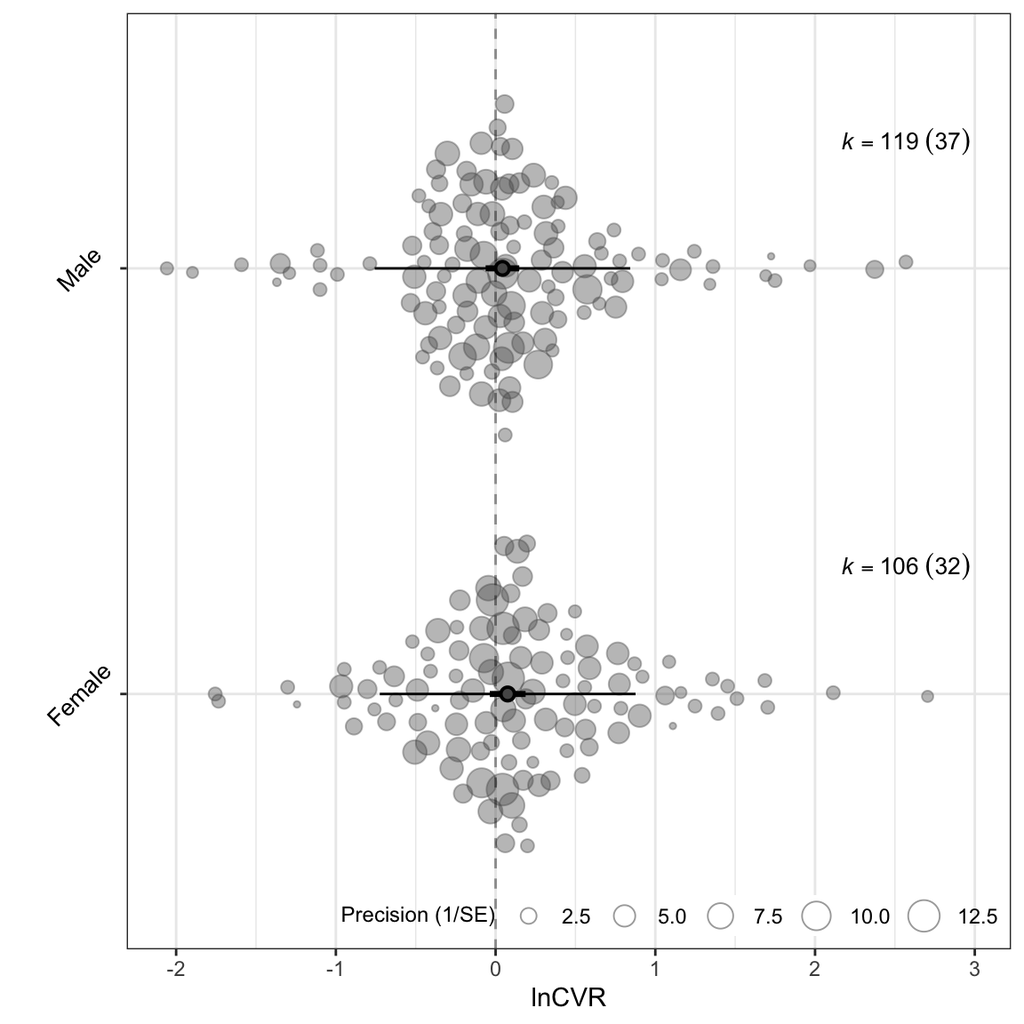

```r
res <- mod_results(m2, mod = "Sex", data = Sex_subset, group = "Study_ID")

Fig1B_sex <- orchard_plot(res, mod = "Sex", group = "Study_ID", xlab = "lnCVR", alpha=0.4) +
theme(axis.text.y = element_text(angle = 45))+ scale_colour_manual(values = c("grey34","grey34")) + scale_fill_manual(values = c("grey34","grey34"))

Fig1B_sex
```

#### DR

##### Without intercept

```r
m3 <-rma.mv(yi=lnCVR, V=v_lnCVR, mods=~Sex-1, random=list(~1|Species, ~1|Study_ID, ~1|ID), data=DR, method="REML", test="t")
m3
```

```
##
## Multivariate Meta-Analysis Model (k = 193; method: REML)
##
## Variance Components:
##
##             estim    sqrt  nlvls  fixed    factor
## sigma^2.1  0.0000  0.0000      5     no   Species
## sigma^2.2  0.0241  0.1552     38     no  Study_ID
## sigma^2.3  0.1913  0.4374    193     no        ID
##
## Test for Residual Heterogeneity:
## QE(df = 191) = 728.8287, p-val < .0001
##
## Test of Moderators (coefficients 1:2):
## F(df1 = 2, df2 = 191) = 0.6771, p-val = 0.5093
##
## Model Results:
##
##            estimate      se    tval   df    pval    ci.lb   ci.ub
## Sexfemale    0.0805  0.0723  1.1134  191  0.2669  -0.0621  0.2230
## Sexmale      0.0369  0.0650  0.5671  191  0.5713  -0.0914  0.1651
##
## ---
## Signif. codes:  0 '***' 0.001 '**' 0.01 '*' 0.05 '.' 0.1 ' ' 1
```

```r
r2_ml(m3)
```

```
##    R2_marginal R2_conditional
##    0.002194878    0.113762571
```

###### Correcting for PB

```r
m3a <- rma.mv(yi=lnVR, V=v_lnVR, mods=~Sex-1 + small_n + scale(Year, scale=F) , random=list(~1|Species, ~1|Study_ID, ~1|ID), data=DR, method="REML", test="t")
m3a
```

```
##
## Multivariate Meta-Analysis Model (k = 193; method: REML)
##
## Variance Components:
##
##             estim    sqrt  nlvls  fixed    factor
## sigma^2.1  0.0000  0.0000      5     no   Species
## sigma^2.2  0.0336  0.1833     38     no  Study_ID
## sigma^2.3  0.1276  0.3573    193     no        ID
##
## Test for Residual Heterogeneity:
## QE(df = 189) = 690.2071, p-val < .0001
##
## Test of Moderators (coefficients 1:4):
## F(df1 = 4, df2 = 189) = 3.6313, p-val = 0.0071
##
## Model Results:
##
##                         estimate      se     tval   df    pval    ci.lb   ci.ub
## Sexfemale                 0.2422  0.0821   2.9511  189  0.0036   0.0803  0.4041
## Sexmale                   0.2045  0.0757   2.7035  189  0.0075   0.0553  0.3538
## small_n                  -0.3752  0.4385  -0.8555  189  0.3934  -1.2403  0.4899
## scale(Year, scale = F)   -0.0011  0.0027  -0.4084  189  0.6835  -0.0065  0.0042
##
## Sexfemale               **
## Sexmale                 **
## small_n
## scale(Year, scale = F)
##
## ---
## Signif. codes:  0 '***' 0.001 '**' 0.01 '*' 0.05 '.' 0.1 ' ' 1
```

```r
r2_ml(m3a)
```

```
##    R2_marginal R2_conditional
##      0.0358855      0.2368286
```

##### With intercept

```r
#With intercept. The sexes don't differ from each other in their response
m3b <-  rma.mv(yi=lnCVR, V=v_lnCVR, mods=~Sex, random=list(~1|Species, ~1|Study_ID, ~1|ID), data=DR, method="REML", test="t")
m3b
```

```
##
## Multivariate Meta-Analysis Model (k = 193; method: REML)
##
## Variance Components:
##
##             estim    sqrt  nlvls  fixed    factor
## sigma^2.1  0.0000  0.0000      5     no   Species
## sigma^2.2  0.0241  0.1552     38     no  Study_ID
## sigma^2.3  0.1913  0.4374    193     no        ID
##
## Test for Residual Heterogeneity:
## QE(df = 191) = 728.8287, p-val < .0001
##
## Test of Moderators (coefficient 2):
## F(df1 = 1, df2 = 191) = 0.2549, p-val = 0.6142
##
## Model Results:
##
##          estimate      se     tval   df    pval    ci.lb   ci.ub
## intrcpt    0.0805  0.0723   1.1134  191  0.2669  -0.0621  0.2230
## Sexmale   -0.0436  0.0863  -0.5048  191  0.6142  -0.2139  0.1267
##
## ---
## Signif. codes:  0 '***' 0.001 '**' 0.01 '*' 0.05 '.' 0.1 ' ' 1
```

###### Correcting for PB

Results remain consistent

```r
m3c <- rma.mv(yi=lnCVR, V=v_lnCVR, mods=~Sex + small_n + scale(Year, scale=F) , random=list(~1|Species, ~1|Study_ID, ~1|ID), data=DR, method="REML", test="t")
m3c
```

```
##
## Multivariate Meta-Analysis Model (k = 193; method: REML)
##
## Variance Components:
##
##             estim    sqrt  nlvls  fixed    factor
## sigma^2.1  0.0000  0.0000      5     no   Species
## sigma^2.2  0.0201  0.1416     38     no  Study_ID
## sigma^2.3  0.1986  0.4456    193     no        ID
##
## Test for Residual Heterogeneity:
## QE(df = 189) = 719.8386, p-val < .0001
##
## Test of Moderators (coefficients 2:4):
## F(df1 = 3, df2 = 189) = 0.5063, p-val = 0.6784
##
## Model Results:
##
##                         estimate      se     tval   df    pval    ci.lb   ci.ub
## intrcpt                   0.0459  0.0870   0.5278  189  0.5983  -0.1257  0.2175
## Sexmale                  -0.0481  0.0869  -0.5535  189  0.5806  -0.2195  0.1233
## small_n                   0.3774  0.4119   0.9163  189  0.3607  -0.4351  1.1899
## scale(Year, scale = F)    0.0015  0.0028   0.5429  189  0.5878  -0.0040  0.0070
##
## intrcpt
## Sexmale
## small_n
## scale(Year, scale = F)
##
## ---
## Signif. codes:  0 '***' 0.001 '**' 0.01 '*' 0.05 '.' 0.1 ' ' 1
```

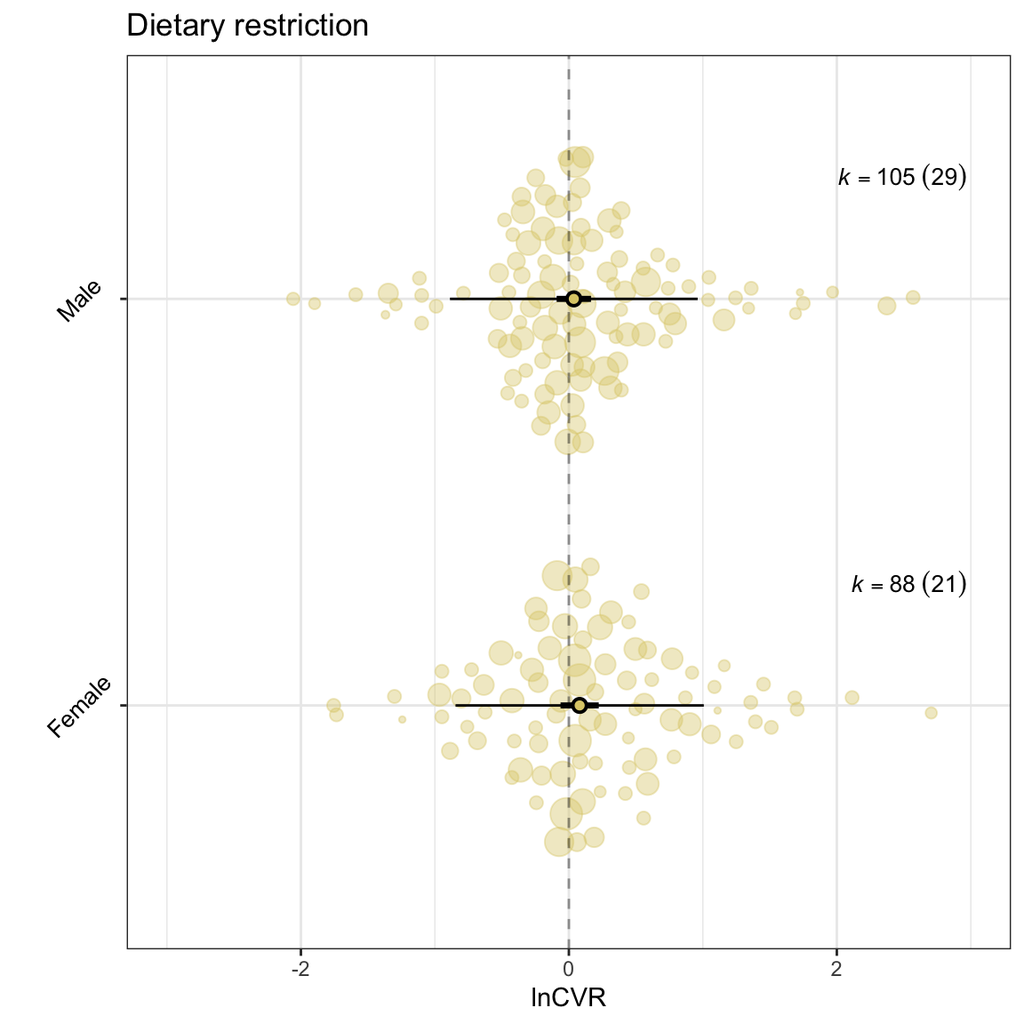

```r
res <- mod_results(m3, mod = "Sex", data = DR, group = "Study_ID")

Fig1B_DR <- orchard_plot(res, mod = "Sex", group = "Study_ID", xlab = "lnCVR", alpha=0.4) +
theme(axis.text.y = element_text(angle = 45)) + scale_colour_manual(values = c("#DDCC77","#DDCC77"))  + scale_fill_manual(values = c("#DDCC77","#DDCC77")) + ggtitle("Dietary restriction")+ theme(legend.position = "none")+ ylim(-3, 3)

Fig1B_DR
```

#### Rapamycin

##### Without intercept

```r
#without intercept: Rapa is not significant in either sex
m4 <-rma.mv(yi=lnCVR, V=v_lnCVR, mods=~Sex-1, random=list(~1|Species, ~1|Study_ID, ~1|ID), data=Rapa, method="REML", test="t")
m4
```

```
##
## Multivariate Meta-Analysis Model (k = 24; method: REML)
##
## Variance Components:
##
##             estim    sqrt  nlvls  fixed    factor
## sigma^2.1  0.0000  0.0000      1    yes   Species
## sigma^2.2  0.0000  0.0000      8     no  Study_ID
## sigma^2.3  0.0336  0.1832     24     no        ID
##
## Test for Residual Heterogeneity:
## QE(df = 22) = 39.8804, p-val = 0.0112
##
## Test of Moderators (coefficients 1:2):
## F(df1 = 2, df2 = 22) = 0.6421, p-val = 0.5358
##
## Model Results:
##
##            estimate      se    tval  df    pval    ci.lb   ci.ub
## Sexfemale    0.0838  0.0768  1.0921  22  0.2866  -0.0754  0.2430
## Sexmale      0.0268  0.0885  0.3024  22  0.7652  -0.1568  0.2104
##
## ---
## Signif. codes:  0 '***' 0.001 '**' 0.01 '*' 0.05 '.' 0.1 ' ' 1
```

```r
r2_ml(m4)
```

```
##    R2_marginal R2_conditional
##     0.02400003     0.02400003
```

###### Correcting for PB

Results remain consistent

```r
m4a <- rma.mv(yi=lnCVR, V=v_lnCVR, mods=~Sex-1 + small_n + scale(Year, scale=F) , random=list(~1|Species, ~1|Study_ID, ~1|ID), data=Rapa, method="REML", test="t")
m4a
```

```
##
## Multivariate Meta-Analysis Model (k = 24; method: REML)
##
## Variance Components:
##
##             estim    sqrt  nlvls  fixed    factor
## sigma^2.1  0.0000  0.0000      1    yes   Species
## sigma^2.2  0.0045  0.0671      8     no  Study_ID
## sigma^2.3  0.0270  0.1643     24     no        ID
##
## Test for Residual Heterogeneity:
## QE(df = 20) = 35.0143, p-val = 0.0200
##
## Test of Moderators (coefficients 1:4):
## F(df1 = 4, df2 = 20) = 1.1114, p-val = 0.3787
##
## Model Results:
##
##                         estimate      se     tval  df    pval    ci.lb   ci.ub
## Sexfemale                 0.1024  0.1201   0.8527  20  0.4039  -0.1481  0.3530
## Sexmale                   0.0774  0.1232   0.6278  20  0.5373  -0.1797  0.3344
## small_n                  -0.4893  1.1878  -0.4119  20  0.6848  -2.9669  1.9884
## scale(Year, scale = F)   -0.0256  0.0151  -1.6937  20  0.1058  -0.0572  0.0059
##
## Sexfemale
## Sexmale
## small_n
## scale(Year, scale = F)
##
## ---
## Signif. codes:  0 '***' 0.001 '**' 0.01 '*' 0.05 '.' 0.1 ' ' 1
```

```r
r2_ml(m4a)
```

```
##    R2_marginal R2_conditional
##      0.2833245      0.3857551
```

##### With intercept

```r
#With intercept. The sexes don't differ from each other in their response
m4b <-  rma.mv(yi=lnCVR, V=v_lnCVR, mods=~Sex, random=list(~1|Species, ~1|Study_ID, ~1|ID), data=Rapa, method="REML", test="t")
m4b
```

```
##
## Multivariate Meta-Analysis Model (k = 24; method: REML)
##
## Variance Components:
##
##             estim    sqrt  nlvls  fixed    factor
## sigma^2.1  0.0000  0.0000      1    yes   Species
## sigma^2.2  0.0000  0.0000      8     no  Study_ID
## sigma^2.3  0.0336  0.1832     24     no        ID
##
## Test for Residual Heterogeneity:
## QE(df = 22) = 39.8804, p-val = 0.0112
##
## Test of Moderators (coefficient 2):
## F(df1 = 1, df2 = 22) = 0.2370, p-val = 0.6312
##
## Model Results:
##
##          estimate      se     tval  df    pval    ci.lb   ci.ub
## intrcpt    0.0838  0.0768   1.0921  22  0.2866  -0.0754  0.2430
## Sexmale   -0.0570  0.1172  -0.4869  22  0.6312  -0.3000  0.1860
##
## ---
## Signif. codes:  0 '***' 0.001 '**' 0.01 '*' 0.05 '.' 0.1 ' ' 1
```

###### Correcting for PB

Results remain consistent

```r
m4c <- rma.mv(yi=lnVR, V=v_lnVR, mods=~Sex + small_n + scale(Year, scale=F) , random=list(~1|Species, ~1|Study_ID, ~1|ID), data=Rapa, method="REML", test="t")
m4c
```

```
##
## Multivariate Meta-Analysis Model (k = 24; method: REML)
##
## Variance Components:
##
##             estim    sqrt  nlvls  fixed    factor
## sigma^2.1  0.0000  0.0000      1    yes   Species
## sigma^2.2  0.0560  0.2367      8     no  Study_ID
## sigma^2.3  0.0475  0.2179     24     no        ID
##
## Test for Residual Heterogeneity:
## QE(df = 20) = 65.3208, p-val < .0001
##
## Test of Moderators (coefficients 2:4):
## F(df1 = 3, df2 = 20) = 0.4357, p-val = 0.7299
##
## Model Results:
##
##                         estimate      se     tval  df    pval    ci.lb   ci.ub
## intrcpt                   0.0404  0.1794   0.2253  20  0.8241  -0.3338  0.4147
## Sexmale                  -0.0196  0.1315  -0.1488  20  0.8832  -0.2938  0.2547
## small_n                   0.5079  1.6503   0.3077  20  0.7615  -2.9345  3.9502
## scale(Year, scale = F)   -0.0296  0.0273  -1.0854  20  0.2906  -0.0866  0.0273
##
## intrcpt
## Sexmale
## small_n
## scale(Year, scale = F)
##
## ---
## Signif. codes:  0 '***' 0.001 '**' 0.01 '*' 0.05 '.' 0.1 ' ' 1
```

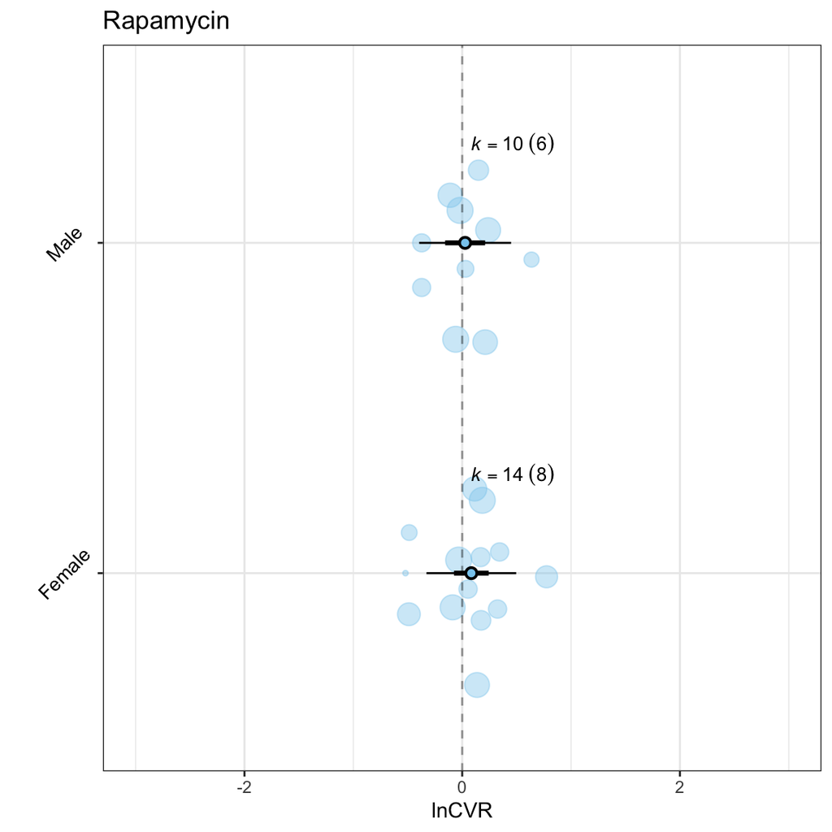

```r
res <- mod_results(m4, mod = "Sex", data = Rapa, group = "Study_ID")

Fig1B_rapa <- orchard_plot(res, mod = "Sex", group = "Study_ID", xlab = "lnCVR", alpha=0.4) +
theme(axis.text.y = element_text(angle = 45))+ scale_colour_manual(values = c("#88CCEE","#88CCEE"))  + scale_fill_manual(values = c("#88CCEE","#88CCEE")) + ggtitle("Rapamycin")+ theme(legend.position = "none")+ ylim(-3, 3)

Fig1B_rapa
```

#### Metformin

##### Without intercept

```r
#Needed to use an optimiser (same as original paper)
m5 <-rma.mv(yi=lnCVR, V=v_lnCVR, mods=~Sex-1, random=list(~1|Species, ~1|Study_ID, ~1|ID), data=Met, method="REML", test="t", control = list(optimizer = "optim", optmethod = "Nelder-Mead"))
m5
```

```
##
## Multivariate Meta-Analysis Model (k = 8; method: REML)
##
## Variance Components:
##
##             estim    sqrt  nlvls  fixed    factor
## sigma^2.1  0.0000  0.0000      2     no   Species
## sigma^2.2  0.0308  0.1754      5     no  Study_ID
## sigma^2.3  0.0000  0.0000      8     no        ID
##
## Test for Residual Heterogeneity:
## QE(df = 6) = 6.7064, p-val = 0.3489
##
## Test of Moderators (coefficients 1:2):
## F(df1 = 2, df2 = 6) = 0.4619, p-val = 0.6507
##
## Model Results:
##
##            estimate      se    tval  df    pval    ci.lb   ci.ub
## Sexfemale    0.0207  0.1548  0.1336   6  0.8981  -0.3581  0.3994
## Sexmale      0.1522  0.1591  0.9564   6  0.3758  -0.2372  0.5415
##
## ---
## Signif. codes:  0 '***' 0.001 '**' 0.01 '*' 0.05 '.' 0.1 ' ' 1
```

```r
r2_ml(m5)
```

```
##    R2_marginal R2_conditional
##      0.1384084      1.0000000
```

###### Correcting for PB

Results remain consistent

```r
m5a <- rma.mv(yi=lnCVR, V=v_lnCVR, mods=~Sex-1 + small_n + scale(Year, scale=F) , random=list(~1|Species, ~1|Study_ID, ~1|ID), data=Met, method="REML", test="t", control = list(optimizer = "optim", optmethod = "Nelder-Mead"))
m5a
```

```
##
## Multivariate Meta-Analysis Model (k = 8; method: REML)
##
## Variance Components:
##
##             estim    sqrt  nlvls  fixed    factor
## sigma^2.1  0.0000  0.0000      2     no   Species
## sigma^2.2  0.0223  0.1494      5     no  Study_ID
## sigma^2.3  0.0000  0.0000      8     no        ID
##
## Test for Residual Heterogeneity:
## QE(df = 4) = 3.8835, p-val = 0.4220
##
## Test of Moderators (coefficients 1:4):
## F(df1 = 4, df2 = 4) = 0.5751, p-val = 0.6974
##
## Model Results:
##
##                         estimate      se     tval  df    pval    ci.lb   ci.ub
## Sexfemale                 0.0068  0.1777   0.0381   4  0.9715  -0.4867  0.5003
## Sexmale                   0.4296  0.2978   1.4427   4  0.2226  -0.3971  1.2564
## small_n                  -0.9162  1.3714  -0.6681   4  0.5407  -4.7239  2.8915
## scale(Year, scale = F)   -0.1003  0.0941  -1.0658   4  0.3466  -0.3617  0.1610
##
## Sexfemale
## Sexmale
## small_n
## scale(Year, scale = F)
##
## ---
## Signif. codes:  0 '***' 0.001 '**' 0.01 '*' 0.05 '.' 0.1 ' ' 1
```

```r
r2_ml(m5a)
```

```
##    R2_marginal R2_conditional
##      0.5616381      1.0000000
```

##### With intercept

```r
#With intercept. The sexes don't differ from each other in their response
m5b <-  rma.mv(yi=lnCVR, V=v_lnCVR, mods=~Sex, random=list(~1|Species, ~1|Study_ID, ~1|ID), data=Met, method="REML", test="t", control = list(optimizer = "optim", optmethod = "Nelder-Mead"))
m5b
```

```
##
## Multivariate Meta-Analysis Model (k = 8; method: REML)
##
## Variance Components:
##
##             estim    sqrt  nlvls  fixed    factor
## sigma^2.1  0.0000  0.0000      2     no   Species
## sigma^2.2  0.0308  0.1754      5     no  Study_ID
## sigma^2.3  0.0000  0.0000      8     no        ID
##
## Test for Residual Heterogeneity:
## QE(df = 6) = 6.7064, p-val = 0.3489
##
## Test of Moderators (coefficient 2):
## F(df1 = 1, df2 = 6) = 0.3653, p-val = 0.5677
##
## Model Results:
##
##          estimate      se    tval  df    pval    ci.lb   ci.ub
## intrcpt    0.0207  0.1548  0.1336   6  0.8981  -0.3581  0.3994
## Sexmale    0.1315  0.2176  0.6044   6  0.5677  -0.4008  0.6638
##
## ---
## Signif. codes:  0 '***' 0.001 '**' 0.01 '*' 0.05 '.' 0.1 ' ' 1
```

###### Correcting for PB

Results remain consistent

```r
m5c <- rma.mv(yi=lnVR, V=v_lnVR, mods=~Sex + small_n + scale(Year, scale=F) , random=list(~1|Species, ~1|Study_ID, ~1|ID), data=Met, method="REML", test="t", control = list(optimizer = "optim", optmethod = "Nelder-Mead"))
m5c
```

```
##
## Multivariate Meta-Analysis Model (k = 8; method: REML)
##
## Variance Components:
##
##             estim    sqrt  nlvls  fixed    factor
## sigma^2.1  0.0000  0.0000      2     no   Species
## sigma^2.2  0.0000  0.0000      5     no  Study_ID
## sigma^2.3  0.0000  0.0000      8     no        ID
##
## Test for Residual Heterogeneity:
## QE(df = 4) = 0.7538, p-val = 0.9445
##
## Test of Moderators (coefficients 2:4):
## F(df1 = 3, df2 = 4) = 0.5177, p-val = 0.6923
##
## Model Results:
##
##                         estimate      se     tval  df    pval    ci.lb   ci.ub
## intrcpt                   0.1753  0.1297   1.3508   4  0.2481  -0.1850  0.5355
## Sexmale                   0.1919  0.2577   0.7446   4  0.4979  -0.5235  0.9072
## small_n                  -0.7793  1.0900  -0.7149   4  0.5142  -3.8058  2.2472
## scale(Year, scale = F)   -0.0851  0.0723  -1.1766   4  0.3046  -0.2860  0.1157
##
## intrcpt
## Sexmale
## small_n
## scale(Year, scale = F)
##
## ---
## Signif. codes:  0 '***' 0.001 '**' 0.01 '*' 0.05 '.' 0.1 ' ' 1
```

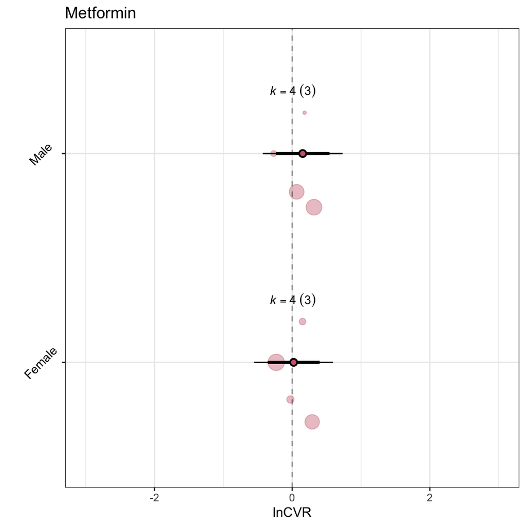

```r
res <- mod_results(m5, mod = "Sex", data = Met, group = "Study_ID")

Fig1B_met <- orchard_plot(res, mod = "Sex", group = "Study_ID", xlab = "lnCVR", alpha=0.4) +
theme(axis.text.y = element_text(angle = 45))+ scale_colour_manual(values = c("#CC6677","#CC6677"))  + scale_fill_manual(values = c("#CC6677","#CC6677")) + ggtitle("Metformin")+ theme(legend.position = "none")+ ylim(-3, 3)

Fig1B_met
```

```r
Fig1B_sex <- (Fig1B_DR / Fig1B_met/ Fig1B_rapa)
```

# Figures

## Fig.1

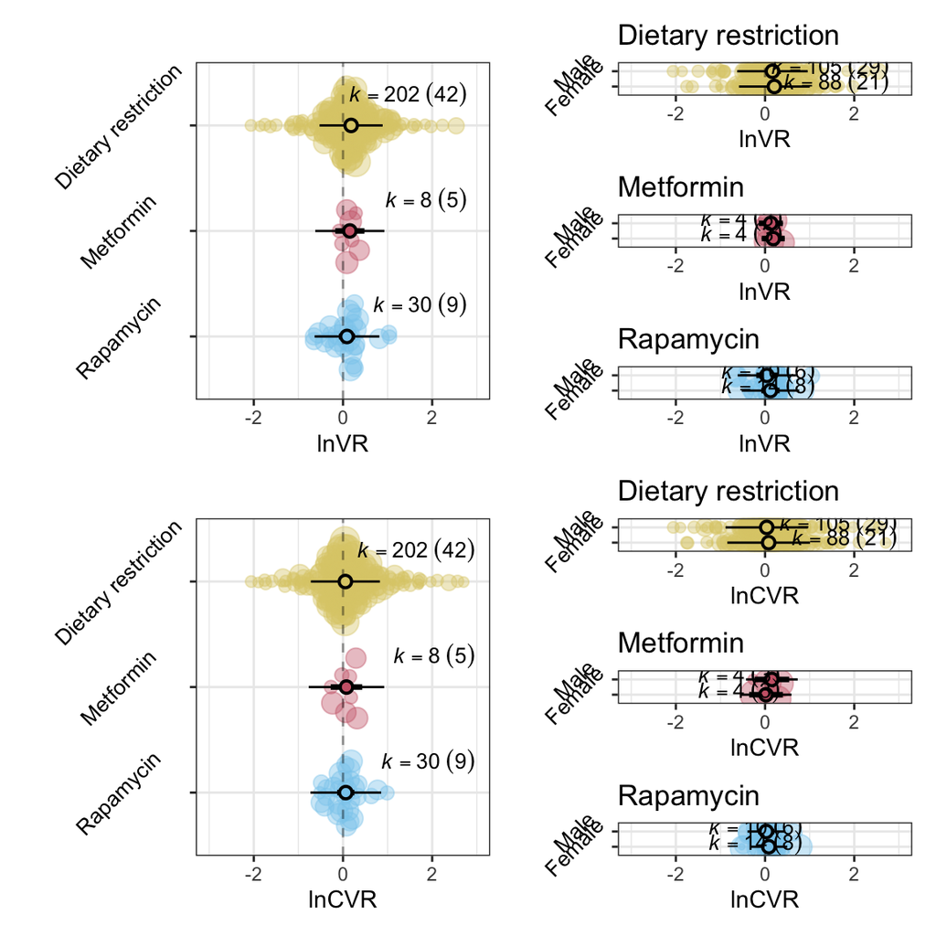

```r
Fig1A <- (Fig1A | Fig1A_sex)

Fig1B <- (Fig1B | Fig1B_sex)

Fig1 <-(Fig1A / Fig1B)
Fig1
```

```r
# exported as 20 x 15 inch PDF - landscape
```